# Proyecto Final

Inteligencia de Negocios y Mineria de Datos

Jose Aguilar, Eilyn Salazar, Crisia Piedra

1 de Junio, 2020

# Fase de entendimiento del negocio

## Determinar los objetivos de negocio

### Objetivos de negocio

1. Incrementar las ventas enfocándose en los diferentes tipos de clientes
2. Mejorar la planeación de presupuestos mensuales a partir de los estimados de ventas a futuro.

### Criterios de éxito (en términos de negocio)

1. Identificar los 3 segmentos de mercado más rentables para la empresa a fin de orientar la estrategia de ventas.
2. Mejorar las estimaciones de ventas mensuales en un 20% de su valor real.

## Evaluación de la situación actual

Actualmente la compañía XYZ no cuenta con controles para crear sus presupuestos, lo cual hace que termine gastando mas o menos de lo que le producen las ventas y no tiene en general un sistema de *forecast* efectivo. Por esta razón desea optimizar la gestión de sus presupeustos a partir de la información histórica disponible sobre las ventas de los diferentes productos que se comercializan.

Por otra parte, el departamento de mercadeo de la empresa desea optimizar su presupuesto enfocando sus esfuerzos en los clientes que son más rentables para la compañía para esto está considerando crear un programa de fidelidad, sin embargo no cuenta con información sobre el perfil de sus mejores clientes.

### Inventario de recursos(datos, personal, TI)

#### Datos

- Datos de ventas históricos de un año.

#### Personal

- 1 patrocinador del proyecto representando la gerencia.
- 1 experto del área de mercadeo para apoyar la estrategia del negocio.
- 1 analista de datos con conocimiento de los sistemas y fuentes de datos.
- 1 desarrollador.

#### TI

Un ambiente virtualizado en la nube con las siguientes características. * OS: Window Server 2016 * RAM: 32 GB * CPU: @2.4 GHz 2.39 GHz (8 processors)

#### Software

1. R y RStudio: Para análisis de datos.
2. MySQL y MySQL Workbench: Fuentes, almacenamiento de datos y herramientas de modelado y consulta.
3. Tableau: Visualización de datos
4. Notepad++ y Visual Studio Code: Desarrollo y revisión de logs de sistema.

### Requerimientos

#### Seguridad

- Solo la gerencia de mercadeo y la gerencia general tendrá acceso a los resultados de la investigación realizada.

#### Legales /Confidencialidad

- Considerando las políticas de confidencialidad y el manejo de los datos personales de los clientes, este proyecto no debe hacer uso de datos personales para su análisis.

#### Implementación y mantenimiento

- Considerando que se utilizará un ambiente virtualizado en la nube, se requiere el uso de VPNs para el acceso al área de desarrollo.
- Todos los equipos utilizados para el análisis deben contar con los parches de sistema operativo y antivirus actualizado.
- El despliegue de los resultados del modelo, y reportes generados se realizará mediante el uso de la herramienta Tableau.

#### Cronograma

- Se estima que la duración del proyecto no podrá exceder más de 1 mes.

### Supuestos

- Se cuenta con acceso a datos de ventas de 1 año.
- La compañía cuenta con los recursos técnicos para satisfacer los requerimientos técnicos del proyecto.
- El proyecto cuenta con la aprobación del negocio y el personal capacitado para ser desarrollado.

### Restricciones

- Solo se cuenta con 1 año de datos históricos.
- La información de clientes es limitada por motivos de privacidad.
- Ausencia de información sobre las categorías de cada producto.

### Riesgos y contingencias

Riesgos y Contingencias

| Tipo.de.Riesgo | Riesgo | Estrategia.de.Contingencia |
| --- | --- | --- |
| Riesgos de Negocio | Cambios en el ambiente de negocio que sean contrarios al objetivo del proyecto. | Involucrar a las diferentes áreas e involucrados de la compañía en la toma de decisiones y presentación de avances del proyecto, para hacer los cambios o adaptaciones requeridos según la necesidad del… |
| Riesgos Organizacionales | Cambios organizacionales | Desarrollo de planes de continuidad del negocio que permitan documentar todo el proceso de desarrollo, documentar roles, responsabilidades y tareas para el manejo de personal de respaldo o backups en … |
|  | Salida de involucrados clave para la compañía. |  |
| Riesgos Financieros | Incremento en el costo estimado del proyecto. | Creación de un presupuesto extraordinario para el manejo de imprevistos financieros durante el proyecto. |
| Riesgos Técnicos | Herramientas seleccionadas para la implementación no cumplen las expectativas | Previo a la fase de implementación y desarrollo realizar una comparación de las herramientas a utilizar. |
| Riesgos de los datos | Datos limitados a 1 año de ventas | Diseñar una estrategia de mantenimiento de los datos, para la evaluación de los objetivos de forma anual. |
|  | Ausencia de datos de nuevos productos del mercado | Diseñar en conjunto con el analista de datos una estrategia de sincronización de los datos periódica para la inclusión de nuevos productos |

### Beneficios

- Reducción de gastos por almacenamiento de inventarios y evitar compras innecesarias.
- Mejora en la tasa de retención de clientes
- Incremento en las ganancias gracias a la mayor disponibilidad de inventario para los productos más vendidos.

## Determinar los objetivos de minería de datos

### Objetivos de minería de datos

- Identificar 3 segmentos de mercados minoristas a partir de las ventas.
- Crear un modelo de predicción de ventas.

### Criterios de éxito (desde la perspectiva de minería de datos)

1. Identificar 3 clústeres de clientes de la compañía basados en su perfil de compras.
2. Evaluar el modelo de predicción a fin de validar que la predicción se encuentre dentro de un 20% de las ventas reales.

##Plan del proyecto

### Evaluación inicial de herramientas y técnicas

Para el desarrollo de este proyecto se utilizará el lenguaje de programación R, y la herramienta RStudio a fin de realizar al proceso de exploración de los datos e identificar las librerías y técnicas de minería de datos más apropiadas para la realización del mismo.

Para el cumplimiento de los objetivos de mineria se utilizaran las técnicas de clustering K-means, y kmedoids, de igual manera para la predicción de las ventas se usara regresión lineal simple y múltiple.

### Plan del proyecto

Se debe señalar que la estimación inicial para el desarrollo del proyecto no debe de tardar más de 1 mes y por lo cual se consideran 24 días hábiles para la implementación del mismo, los cuales son distribuidos de la siguiente manera.

Plan de Proyecto

Fases

Actividades

Riesgos

Contingencias

Recurso

Entendimiento del negocio

1. Determinar los objetivos del negocio
2. Evaluación de la situación
3. Determinar los objetivos de minería de datos
4. Generar el plan de proyecto.

Falta de disponibilidad de los involucrados. Objetivos definidos no alineados con las necesidades del negocio.

Validación de los objetivos con la gerencia ejecutiva de la compañía. Coordinación a través de conferencias y emails para establecer la fecha de inicio del proyecto. Milestones. Creación de un project roster para la ubicación de los involucrados y sus backups en caso de ser necesario.

Patrocinador Experto en la gerencia de mercadeo

Entendimiento de los datos

1. Recopilación inicial de datos

Describir los datos

Explorar los datos

Verificar la calidad de los datos

Ausencia de productos lanzados recientemente al mercado. Falta de conocimiento de negocio por parte del analista.

En conjunto con el analista de datos, realizar un proceso de verificación y recolección de los datos más recientes en el mercado. Trabajar de la mano con el experto en la gerencia de mercadeo y otros involucrados expertos en el manejo de los datos.

Experto en la gerencia de mercadeo Analista de datos Desarrollador

Preparación de los datos

1. Selección de los datos.

Limpiar los datos.

Construcción de datos

Integrar los datos

Ausencia de valores en múltiples columnas. Determinar las variables que analizar como parte del problema a resolver

Determinar la mejor técnica de imputación de datos, en conjunto con la gerencia de mercadeo. Uso de técnicas como análisis de correlación, análisis de componentes principales para identificar las variables más relevantes para el análisis.

Experto en la gerencia de mercadeo Analista de datos Desarrollador

Modelado

1. Seleccionar la técnica de modelado

Generar diseño de testing

Construir el modelo

Evaluar el modelo

Mal diseño en la implementación del modelo Las técnicas de minería seleccionados no proveen los resultados esperados La duración en la ejecución de los modelos y su entrenamiento tarda más de lo estimado

Uso de múltiples modelos al aplicar una misma técnica de minería. Uso de múltiples técnicas de minería.

Analista de datos Desarrollador

Evaluación

1. Evaluar los Resultados

Revisión del proceso

Determinar Pasos a Seguir

Insatisfacción de los involucrados con los resultados del proyecto

Aumento de las capacidades computacionales de los equipos en los que se realiza el proceso de entrenamiento. Replanteamiento de las metas y objetivos de la investigación con los involucrados del proyecto, añadiendo nuevas variables/datos adicionales

Experto en la gerencia de mercadeo Analista de datos Desarrollador

Implementación (Deployment)

1. Plan de despliegue

Plan de Monitoreo y mantenimiento

Producción del reporte final

Revisión del proyecto

Aumento en el costo de los recursos técnicos disponibles. Variación en el alcance del proyecto.

Comparación de proveedores que ofrecen servicios en la nube y se adecuen a las necesidades del proyecto. Establecimiento de una condición de cierre del proyecto y creación de un plan de administración para nuevas fases

Analista de datos Desarrollador

# Fase de entendimiento de los datos

## Recopilación inicial de datos

### Lista de datasets requeridos

Para el desarrollo de este trabajo se hará uso del conjunto de datos“Online Retail”. Este es un conjunto de datos transnacionales que contiene todas las transacciones que ocurren entre el 12/01/2010 y el 12/09/2011 para un minorista en línea registrado en el Reino Unido y sin tienda. La compañía vende principalmente regalos únicos para toda ocasión.

#### Ubicación de los datasets

Este conjunto de datos se encuentra disponible en el Machine Learning Repository a través del siguiente url.

#### Método de acceso

El conjunto de datos puede ser descargado en formato .xlsx a través del siguiente link http://archive.ics.uci.edu/ml/machine-learning-databases/00352/

## Descripción de los datos

Descripción de atributos

| Variable | Descripción | Tipo |
| --- | --- | --- |
| InvoiceNo | Número de factura Nominal; un número integral de 6 dígitos asignado exclusivamente a cada transacción. Si este código comienza con la letra ‘c’; indica una cancelación. | Cualitativa Nominal (Alfanumérico) |
| StockCode | Código de producto (artículo). Nominal; un número integral de 5 dígitos asignado exclusivamente a cada producto distinto. | Cualitativa Nominal (Alfanumérico) |
| Description | Nombre del producto (artículo). Nominal. | Cualitativa Nominal (Alfanumérico) |
| Quantity | Las cantidades de cada producto (artículo) por transacción. Numérico. | Cuantitativa Continua (Numérico) |
| InvoiceDate | Fecha y hora de inicio. Numérico; el día y la hora en que se generó cada transacción. | Cuantitativa Discreta (Fecha) |
| UnitPrice | Precio unitario. Numérico; precio del producto por unidad en libras esterlinas. | Cuantitativa Continua (Numérico) |
| CustomerID | Número de cliente. Nominal; un número integral de 5 dígitos asignado exclusivamente a cada cliente. | Cualitativa Nominal (Alfanumérico) |
| Country | Nombre del país. Nominal; el nombre del país donde reside cada cliente. | Cualitativa Nominal (Alfanumérico) |

## Exploración de los datos

Se aplicó la función summary para la obtención de las estadísticas básicas de cada variable del conjunto de datos. Por medio de este análisis es posible observar elementos interesantes como los valores mínimos y máximos de las cantidades.

```r
retail<-read_excel("Online Retail.xlsx")
summary(retail)
```

```
##   InvoiceNo          StockCode         Description
##  Length:541909      Length:541909      Length:541909
##  Class :character   Class :character   Class :character
##  Mode  :character   Mode  :character   Mode  :character
##
##
##
##
##     Quantity          InvoiceDate                    UnitPrice
##  Min.   :-80995.00   Min.   :2010-12-01 08:26:00   Min.   :-11062.06
##  1st Qu.:     1.00   1st Qu.:2011-03-28 11:34:00   1st Qu.:     1.25
##  Median :     3.00   Median :2011-07-19 17:17:00   Median :     2.08
##  Mean   :     9.55   Mean   :2011-07-04 13:34:57   Mean   :     4.61
##  3rd Qu.:    10.00   3rd Qu.:2011-10-19 11:27:00   3rd Qu.:     4.13
##  Max.   : 80995.00   Max.   :2011-12-09 12:50:00   Max.   : 38970.00
##
##    CustomerID       Country
##  Min.   :12346    Length:541909
##  1st Qu.:13953    Class :character
##  Median :15152    Mode  :character
##  Mean   :15288
##  3rd Qu.:16791
##  Max.   :18287
##  NA's   :135080
```

En el summary podemos ver algunas cosas interesantes, como por ejempo:

- Se identifican posibles valores default para variables como quantity con -80995.00 - es un valor irreal para una cantidad, por lo que es posible que sea el valor por defecto de este campo, y se obtiene como el valor mínimo en ese campo.
- Otro de los detalles que logra observarse es como variables como CustomerID y Description tienen valores NA.

Nota: En el caso de description es posible observar líneas en blanco al revisar las observaciones.

Para efectos de la tarea se le dará prioridad a los siguientes campos:

- InvoiceNo: Sera utilizado para agrupar las compras.
- CustomerID: Sera utilizado para identificar los clientes que seran agrupados.
- Total: Campo derivado (ver siguiente sección) que facilitará los calculos de las ventas.
- InvoiceDay: Variable creada con la fecha del día de la compra

Nota:

Las siguiente variables son utilizadas para la creacion del campo Total, mas no seran utilizadas directamente.

- Quantity: Sera utilizado para determinar el conjunto de productos mas vendidos.
- UnitPrice: Sera utilizado para determinar, junto con Quantity. las ventas a predecir.

#### Compras de clientes

De estos datos y basado en estas observaciones prelminares es posible crear algunos campos adicionales que pueden ayudar a la hora de manipularlos. Para inciar, vamos a crear estos dos campos adicionales:

| Campo | Descripción | Tipo |
| --- | --- | --- |
| Total | Total de la compra del producto, resultado de multiplicar UnitPrice por Quantity | Numérico |
| InvoiceDay | Fecha de la compra sin la hora para sumarizar por día las compras | Fecha |

```r
retail$Total <- retail$UnitPrice * retail$Quantity
retail$InvoiceDay <- as.Date(format(retail$InvoiceDate,"%Y-%m-%d"))
```

Ademas podemos observar que existen variables que son actualmente hileras (strings) o numeros pero en realidad representan un factor, por lo que se realizan las siguientes conversiones para estas columnas:

| Campo | Conversión | Nuevo Tipo |
| --- | --- | --- |
| StockCode | Convertirlo a un factor | Factor |
| Description | Convertirlo a un factor | Factor |
| Country | Convertirlo a un factor | Factor |
| CustomerID | Convertirlo a un factor | Factor |

```r
retail$StockCode <- as.factor(retail$StockCode)
retail$Description <- as.factor(retail$Description)
retail$Country <- as.factor(retail$Country)
retail$CustomerID <- as.factor(retail$CustomerID)
```

Podemos revisar algunas de estas variables y como se relacionan. Por ejemplo, en el siguiente gráfico se muestra el resultado de la multiplicación de las variables *UnitPrice* y *Quantity* (variable *Total*) agrupadas por cliente, y se muestran las compras totales de los 10 primeros clientes de la tabla:

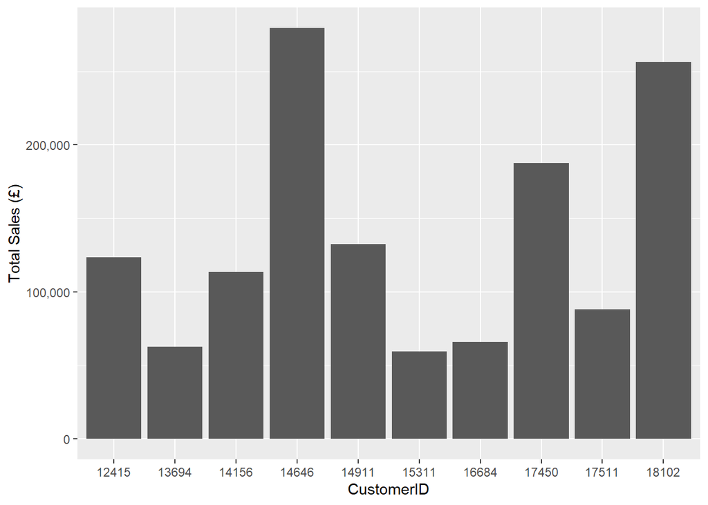

```r
por_cliente <- retail[!is.na(retail$CustomerID),] %>%
  group_by(CustomerID) %>%
  summarise_at(vars(Total),funs(sum(.))) %>%
  arrange(desc(Total))
pp<-ggplot(data=head(por_cliente,10), aes(x=CustomerID,y=Total)) +
  geom_bar(stat="identity") +
  scale_y_continuous(name="Total Sales (£)", labels = scales::comma)
pp
```

A través del customerID podemos ver las compras totales del cliente por ejemplo el cliente 14646 realizó compras totales por un monto de ￡279489 en 721 productos diferentes.

Podemos ver que productos compra:

```r
#Agrupamos por productos:
un_cliente_productos <- subset(retail, CustomerID==14646) %>%
  group_by(StockCode,Description) %>%
  summarise_at(vars(Quantity,Total),list(~sum(.))) %>%
  arrange(desc(Total))
un_cliente_totales<-sum(un_cliente_productos$Total)
un_cliente_productos_diferentes<-nrow(un_cliente_productos)
```

Las compras totales del cliente son:

```r
print(un_cliente_totales)
```

```
## [1] 279489
```

en la siguiente cantidad de productos:

```r
print(un_cliente_productos_diferentes)
```

```
## [1] 721
```

La siguiente tabla es una muestra de los productos que adquirió, la cantidad que adquirió y el total de la venta:

```r
kable(head(un_cliente_productos,10),"html", booktabs = T)%>%
kable_styling(latex_options = "striped")
```

| StockCode | Description | Quantity | Total |
| --- | --- | --- | --- |
| 23084 | RABBIT NIGHT LIGHT | 4801 | 9568.48 |
| 22326 | ROUND SNACK BOXES SET OF4 WOODLAND | 3120 | 7956.00 |
| 22629 | SPACEBOY LUNCH BOX | 4492 | 7415.40 |
| 22630 | DOLLY GIRL LUNCH BOX | 4096 | 6758.40 |
| 22328 | ROUND SNACK BOXES SET OF 4 FRUITS | 1584 | 4039.20 |
| 85099B | JUMBO BAG RED RETROSPOT | 2000 | 3468.00 |
| 21731 | RED TOADSTOOL LED NIGHT LIGHT | 2376 | 3459.60 |
| 22423 | REGENCY CAKESTAND 3 TIER | 288 | 3153.60 |
| 22243 | 5 HOOK HANGER RED MAGIC TOADSTOOL | 2016 | 2923.20 |
| 20712 | JUMBO BAG WOODLAND ANIMALS | 1500 | 2629.00 |

Podemos ver que algunos clientes compran grandes cantidades - por ejemplo en este caso, el cliente compró 4801 unidades del producto RABBIT NIGHT LIGHT. Esto nos hace pensar que algunas de las cantidades grandes vistas anterioremente no son anómalas.

Los siguientes gráficos muestran el comportamiento de las ventas en el tiempo, así como la agrupación por país.

Para observar las ventas por día, utilizamos la variable InvoiceDay, con el fin de eliminar la hora de la venta que no es de interés para este análisis.

```r
invoices <- retail %>%
  group_by(InvoiceDay) %>%
  summarise_at(vars(Total),funs(sum(.)))
kable(head(invoices,10),"html", booktabs = T)%>%
  kable_styling(latex_options = "striped")
```

| InvoiceDay | Total |
| --- | --- |
| 2010-12-01 | 58635.56 |
| 2010-12-02 | 46207.28 |
| 2010-12-03 | 45620.46 |
| 2010-12-05 | 31383.95 |
| 2010-12-06 | 53860.18 |
| 2010-12-07 | 45059.05 |
| 2010-12-08 | 44189.84 |
| 2010-12-09 | 52532.13 |
| 2010-12-10 | 57404.91 |
| 2010-12-12 | 17240.92 |

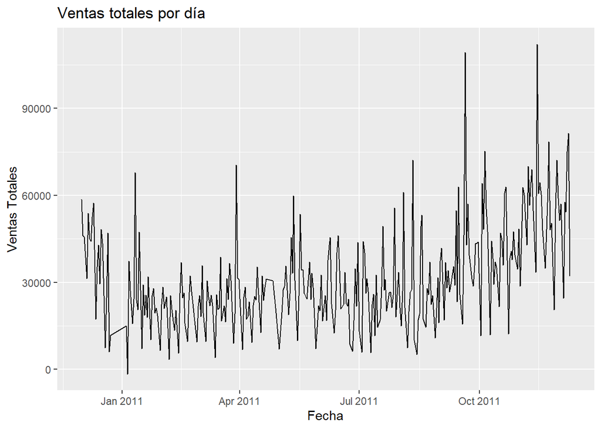

```r
p <- ggplot(invoices, aes(x=InvoiceDay, y=Total)) +
  geom_line() +
  xlab("Fecha") +
  ylab("Ventas Totales") +
  ggtitle("Ventas totales por día")
p
```

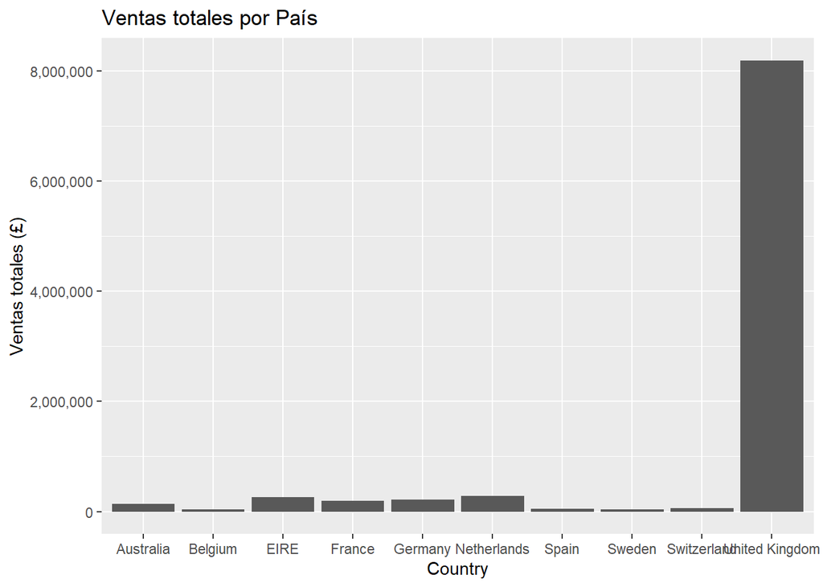

```r
por_pais <- retail %>%
  group_by(Country) %>%
  summarise_at(vars(Total),funs(sum(.))) %>%
  arrange(desc(Total))
pp<-ggplot(data=head(por_pais,10), aes(x=Country,y=Total)) +
  geom_bar(stat="identity") +
  scale_y_continuous(name="Ventas totales (£)", labels = scales::comma) +
  ggtitle("Ventas totales por País")
pp
```

Y podemos ademas observar las cantidades de las ventas por país:

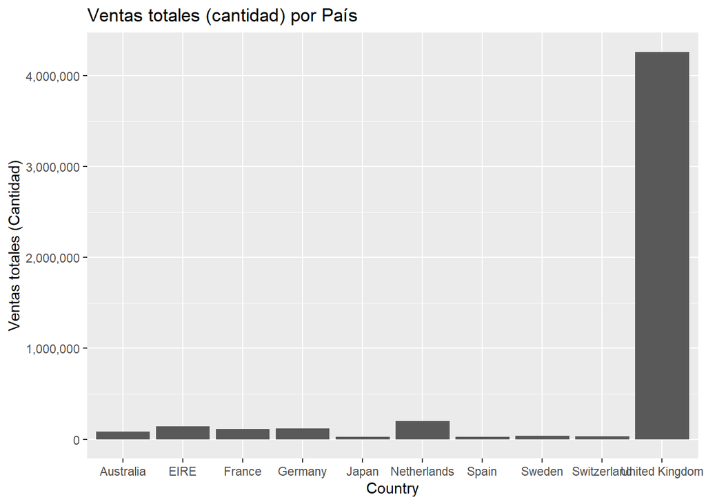

```r
por_cantidad <- retail %>%
  group_by(Country) %>%
  summarise_at(vars(Quantity),funs(sum(.))) %>%
  arrange(desc(Quantity))
pp<-ggplot(data=head(por_cantidad,10), aes(x=Country,y=Quantity)) +
  geom_bar(stat="identity") +
  scale_y_continuous(name="Ventas totales (Cantidad)", labels = scales::comma) +
  ggtitle("Ventas totales (cantidad) por País")
pp
```

## Verificación de la calidad de datos

Uno de los problemas de calidad detectados es el gran número de observaciones en donde el CustomerID tiene un valor NA, es decir no se tiene la información de cuáles fueron los clientes que realizaron las compras, lo cual puede influir en el análisis a realizar al no contar con esta información.

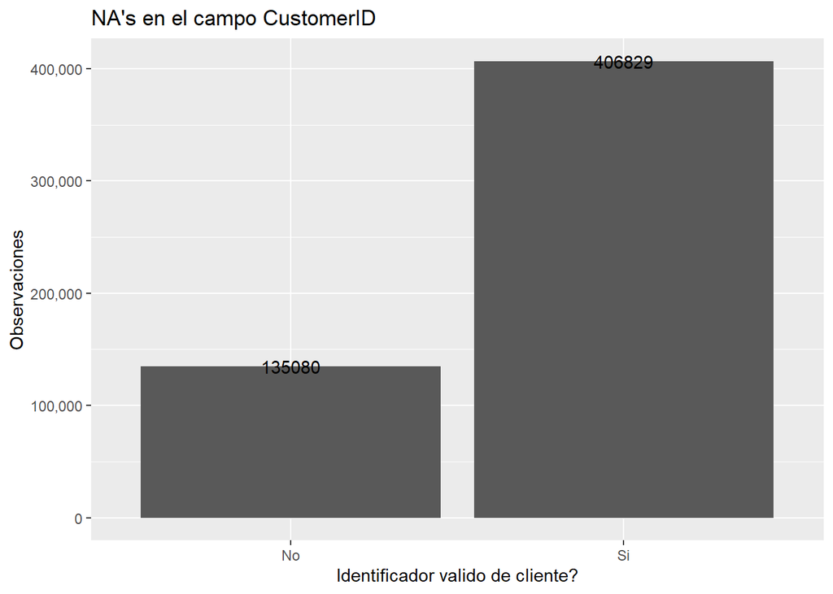

```r
numclientesna <- count(is.na(retail$CustomerID))
library(ggplot2)
tmp_clientes<-data.frame(IdValido=c("Si", "No"), conteo=c(numclientesna[1,2],numclientesna[2,2]), index=1)
ggplot(tmp_clientes,aes(IdValido,conteo)) +
  geom_col(stat="identity")+
  scale_y_continuous(name="Observaciones", labels = scales::comma) +
  labs(x="Identificador valido de cliente?")+
  ggtitle("NA's en el campo CustomerID") +
  geom_text(aes(label=conteo))
```

Como se puede observar, hay 135080 NA - estos registros no pueden ser utilizados para el analisis de clientes a realizar, dejandonos solamente con los 406829 registros restantes.

Así mismo al analizar las variables de quantity y unit price, es posible ver que existen datos que a simple vista son anómalos como se muestra en las siguientes gráficas de caja.

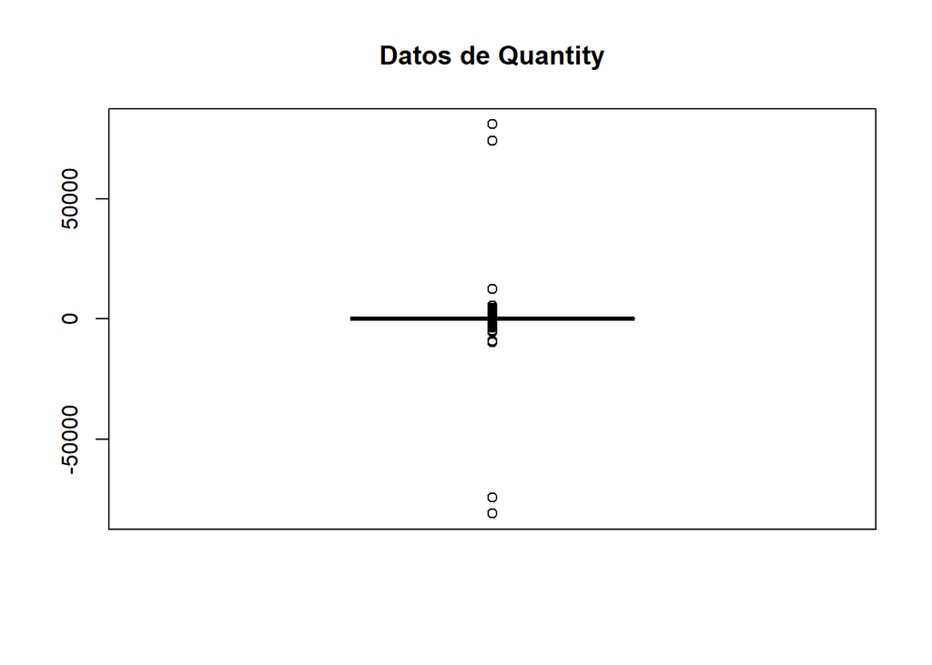

```r
boxplot(retail$Quantity,data=retail,main="Datos de Quantity")
```

De acuerdo con esto, existen 58619 valores “outliers”. Dado que representa un número importante de valores es importante validar estos datos con el experto del negocio a fin de comprender su validez y de no ser completamente correcto, será necesario imputarlos de alguna forma - sin embargo, hay que tener cuidado dado que puede alterar significativamente los resultados.

Podemos hacer el mismo estudio con el campo UnitPrice

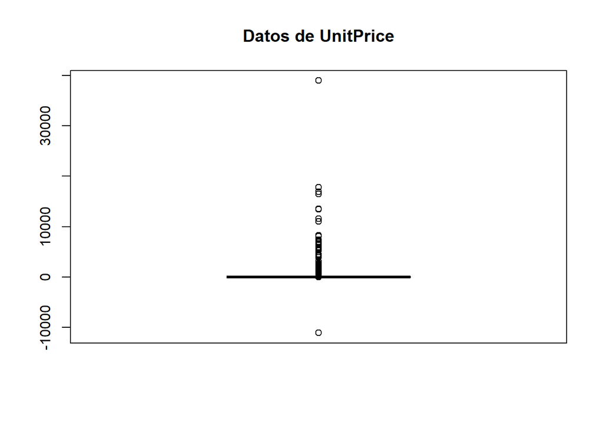

```r
boxplot(retail$UnitPrice,data=retail,main="Datos de UnitPrice")
```

De acuerdo con esto, existen 39627 valores “outliers” para UnitPrice. En este caso debemos hacer un tratamiento similar para los valores de la variable quantity.

Adicionalmente podemos revisar para los valores que representan montos de dinero (UnitPrice) o Cantidades, que los valores tengan sentido - podemos revisar por ejemplo que sean positivos:

Para Unit Price:

```r
UnitPrice_Positivos<- nrow(retail[retail$UnitPrice >= 0,])
UnitPrice_Positivos
```

```
## [1] 541907
```

```r
UnitPrice_Negativos<- nrow(retail[retail$UnitPrice < 0,])
UnitPrice_Negativos
```

```
## [1] 2
```

```r
kable(head(retail[retail$UnitPrice < 0,],10),"html", booktabs = T)%>%
  kable_styling(latex_options = "striped")
```

| InvoiceNo | StockCode | Description | Quantity | InvoiceDate | UnitPrice | CustomerID | Country | Total | InvoiceDay |
| --- | --- | --- | --- | --- | --- | --- | --- | --- | --- |
| A563186 | B | Adjust bad debt | 1 | 2011-08-12 14:51:00 | -11062.06 | NA | United Kingdom | -11062.06 | 2011-08-12 |
| A563187 | B | Adjust bad debt | 1 | 2011-08-12 14:52:00 | -11062.06 | NA | United Kingdom | -11062.06 | 2011-08-12 |

Podemos ver que solamente son dos valores negativos, y que por la descripcion que tienen, probablemente pueden ser ignorados.

Para Quantity:

```r
Quantity_Positivos<- nrow(retail[retail$Quantity >= 0,])
Quantity_Positivos
```

```
## [1] 531285
```

```r
Quantity_Negativos<- nrow(retail[retail$Quantity < 0,])
Quantity_Negativos
```

```
## [1] 10624
```

```r
kable(head(retail[retail$Quantity < 0,]),"html", booktabs = T)%>%
  kable_styling(latex_options = "striped")
```

| InvoiceNo | StockCode | Description | Quantity | InvoiceDate | UnitPrice | CustomerID | Country | Total | InvoiceDay |
| --- | --- | --- | --- | --- | --- | --- | --- | --- | --- |
| C536379 | D | Discount | -1 | 2010-12-01 09:41:00 | 27.50 | 14527 | United Kingdom | -27.50 | 2010-12-01 |
| C536383 | 35004C | SET OF 3 COLOURED FLYING DUCKS | -1 | 2010-12-01 09:49:00 | 4.65 | 15311 | United Kingdom | -4.65 | 2010-12-01 |
| C536391 | 22556 | PLASTERS IN TIN CIRCUS PARADE | -12 | 2010-12-01 10:24:00 | 1.65 | 17548 | United Kingdom | -19.80 | 2010-12-01 |
| C536391 | 21984 | PACK OF 12 PINK PAISLEY TISSUES | -24 | 2010-12-01 10:24:00 | 0.29 | 17548 | United Kingdom | -6.96 | 2010-12-01 |
| C536391 | 21983 | PACK OF 12 BLUE PAISLEY TISSUES | -24 | 2010-12-01 10:24:00 | 0.29 | 17548 | United Kingdom | -6.96 | 2010-12-01 |
| C536391 | 21980 | PACK OF 12 RED RETROSPOT TISSUES | -24 | 2010-12-01 10:24:00 | 0.29 | 17548 | United Kingdom | -6.96 | 2010-12-01 |

Para las cantidades se puede observar que son muchos mas, 10624. Es necesario revisar esto con los analistas del negocio. Sin embargo el hecho que una de las descripciones tenga el texto “Discount” nos hace pensar que tal vez sean por proceso de negocios - una forma de dar descuentos o de realizar devoluciones de productos.

# Fase de preparación de los datos

## Selección de datos:

```r
datos_ge <- retail
summary(datos_ge)
```

```
##   InvoiceNo           StockCode
##  Length:541909      85123A :  2313
##  Class :character   22423  :  2203
##  Mode  :character   85099B :  2159
##                     47566  :  1727
##                     20725  :  1639
##                     84879  :  1502
##                     (Other):530366
##                              Description        Quantity
##  WHITE HANGING HEART T-LIGHT HOLDER:  2369   Min.   :-80995.00
##  REGENCY CAKESTAND 3 TIER          :  2200   1st Qu.:     1.00
##  JUMBO BAG RED RETROSPOT           :  2159   Median :     3.00
##  PARTY BUNTING                     :  1727   Mean   :     9.55
##  LUNCH BAG RED RETROSPOT           :  1638   3rd Qu.:    10.00
##  (Other)                           :530362   Max.   : 80995.00
##  NA's                              :  1454
##   InvoiceDate                    UnitPrice           CustomerID
##  Min.   :2010-12-01 08:26:00   Min.   :-11062.06   17841  :  7983
##  1st Qu.:2011-03-28 11:34:00   1st Qu.:     1.25   14911  :  5903
##  Median :2011-07-19 17:17:00   Median :     2.08   14096  :  5128
##  Mean   :2011-07-04 13:34:57   Mean   :     4.61   12748  :  4642
##  3rd Qu.:2011-10-19 11:27:00   3rd Qu.:     4.13   14606  :  2782
##  Max.   :2011-12-09 12:50:00   Max.   : 38970.00   (Other):380391
##                                                    NA's   :135080
##            Country           Total              InvoiceDay
##  United Kingdom:495478   Min.   :-168469.60   Min.   :2010-12-01
##  Germany       :  9495   1st Qu.:      3.40   1st Qu.:2011-03-28
##  France        :  8557   Median :      9.75   Median :2011-07-19
##  EIRE          :  8196   Mean   :     17.99   Mean   :2011-07-04
##  Spain         :  2533   3rd Qu.:     17.40   3rd Qu.:2011-10-19
##  Netherlands   :  2371   Max.   : 168469.60   Max.   :2011-12-09
##  (Other)       : 15279
```

### Selección de variables clave

- Quantity: Es la variable que nos indica cuales son las existencias que deben existir por cada producto para mejorar las existencias en inventarios basado en las ventas registradas.
- Unit Price: En conjunto con la variable quantity nos permite realizar el cálculo del valor monetario de las ventas realizadas por cliente.
- CustomerID: Nos permite agrupar las compras realizadas por el mismo cliente, esto con el fin de identificar cuáles son los mejores clientes de la compañía.
- Country: Nos permite analizar o agrupar el comportamiento de las compras por país.
- Total: Total es una variable derivada y nos permite obtener el monto total de las compras realizadas por cliente, para analizar cuales son los mejores clientes basados en las mismas.
- InvoiceDay: Se empleara el InvoiceDate para realizar la creacion de variables adicionales asociadas a la dimensión tiempo, como la “frescura” y frecuencia de las compras realizadas por los clientes.

Dado que el dataset solamente contiene 8 campos, no se descartará ninguna variable. Sin embargo si se evaluará descartar observaciones que presenten problemas como los outliers que se describen en la sección de Calidad de datos.

## Limpieza de datos

Basados en lo observado en la seccion de *Calidad de Datos*, podemos eliminar ciertos registros que son aportan a los modelos a realizar.

*Valores negativos en UnitPrice*

Existen dos registros que tienen este campo, UnitPrice, en negativo:

```r
kable(head(datos_ge[datos_ge$UnitPrice < 0,],10),"html", booktabs = T)%>%
  kable_styling(latex_options = "striped")
```

| InvoiceNo | StockCode | Description | Quantity | InvoiceDate | UnitPrice | CustomerID | Country | Total | InvoiceDay |
| --- | --- | --- | --- | --- | --- | --- | --- | --- | --- |
| A563186 | B | Adjust bad debt | 1 | 2011-08-12 14:51:00 | -11062.06 | NA | United Kingdom | -11062.06 | 2011-08-12 |
| A563187 | B | Adjust bad debt | 1 | 2011-08-12 14:52:00 | -11062.06 | NA | United Kingdom | -11062.06 | 2011-08-12 |

```r
retail <- datos_ge[!(datos_ge$UnitPrice < 0),]
kable(head(datos_ge[datos_ge$UnitPrice < 0,],10),"html", booktabs = T)%>%
  kable_styling(latex_options = "striped")
```

| InvoiceNo | StockCode | Description | Quantity | InvoiceDate | UnitPrice | CustomerID | Country | Total | InvoiceDay |
| --- | --- | --- | --- | --- | --- | --- | --- | --- | --- |
| A563186 | B | Adjust bad debt | 1 | 2011-08-12 14:51:00 | -11062.06 | NA | United Kingdom | -11062.06 | 2011-08-12 |
| A563187 | B | Adjust bad debt | 1 | 2011-08-12 14:52:00 | -11062.06 | NA | United Kingdom | -11062.06 | 2011-08-12 |

*Valores negativos en Quantity*

Asimismo se observaron varios valores negativos en el campo Quantity que corresponden a devoluciones y consideran que este parametro no sera utilizado, se proce a removerlas del conjunto de observaciones:

```r
kable(head(datos_ge[datos_ge$Quantity < 0,]),"html", booktabs = T)%>%
  kable_styling(latex_options = "striped")
```

| InvoiceNo | StockCode | Description | Quantity | InvoiceDate | UnitPrice | CustomerID | Country | Total | InvoiceDay |
| --- | --- | --- | --- | --- | --- | --- | --- | --- | --- |
| C536379 | D | Discount | -1 | 2010-12-01 09:41:00 | 27.50 | 14527 | United Kingdom | -27.50 | 2010-12-01 |
| C536383 | 35004C | SET OF 3 COLOURED FLYING DUCKS | -1 | 2010-12-01 09:49:00 | 4.65 | 15311 | United Kingdom | -4.65 | 2010-12-01 |
| C536391 | 22556 | PLASTERS IN TIN CIRCUS PARADE | -12 | 2010-12-01 10:24:00 | 1.65 | 17548 | United Kingdom | -19.80 | 2010-12-01 |
| C536391 | 21984 | PACK OF 12 PINK PAISLEY TISSUES | -24 | 2010-12-01 10:24:00 | 0.29 | 17548 | United Kingdom | -6.96 | 2010-12-01 |
| C536391 | 21983 | PACK OF 12 BLUE PAISLEY TISSUES | -24 | 2010-12-01 10:24:00 | 0.29 | 17548 | United Kingdom | -6.96 | 2010-12-01 |
| C536391 | 21980 | PACK OF 12 RED RETROSPOT TISSUES | -24 | 2010-12-01 10:24:00 | 0.29 | 17548 | United Kingdom | -6.96 | 2010-12-01 |

```r
datos_ge <- datos_ge[!(datos_ge$Quantity < 0),]
kable(head(datos_ge[datos_ge$Quantity < 0,],10),"html", booktabs = T)%>%
  kable_styling(latex_options = "striped")
```

| InvoiceNo | StockCode | Description | Quantity | InvoiceDate | UnitPrice | CustomerID | Country | Total | InvoiceDay |
| --- | --- | --- | --- | --- | --- | --- | --- | --- | --- |

*Eliminación de Observaciones con valores NA*

Al analizar el conjunto de datos se observa que hay algunas observaciones con valores NA en las columnas CustomerID y descripción las cuales son eliminadas.

```r
datos_ge <- datos_ge %>% drop_na(CustomerID, Description)
```

*Manejo de Outliers*

Para revisar los Outliers detectados en la sección de calidad de datos, se ejecuta un summary con el fin de determinar el mínimo, maximo, y otras caracteristicas de las columnas Quantity y UnitPrice:

```r
summary(datos_ge)
```

```
##   InvoiceNo           StockCode
##  Length:397924      85123A :  2035
##  Class :character   22423  :  1724
##  Mode  :character   85099B :  1618
##                     84879  :  1408
##                     47566  :  1397
##                     20725  :  1317
##                     (Other):388425
##                              Description        Quantity
##  WHITE HANGING HEART T-LIGHT HOLDER:  2028   Min.   :    1.00
##  REGENCY CAKESTAND 3 TIER          :  1724   1st Qu.:    2.00
##  JUMBO BAG RED RETROSPOT           :  1618   Median :    6.00
##  ASSORTED COLOUR BIRD ORNAMENT     :  1408   Mean   :   13.02
##  PARTY BUNTING                     :  1397   3rd Qu.:   12.00
##  LUNCH BAG RED RETROSPOT           :  1316   Max.   :80995.00
##  (Other)                           :388433
##   InvoiceDate                    UnitPrice          CustomerID
##  Min.   :2010-12-01 08:26:00   Min.   :   0.000   17841  :  7847
##  1st Qu.:2011-04-07 11:12:00   1st Qu.:   1.250   14911  :  5677
##  Median :2011-07-31 14:39:00   Median :   1.950   14096  :  5111
##  Mean   :2011-07-10 23:43:36   Mean   :   3.116   12748  :  4596
##  3rd Qu.:2011-10-20 14:33:00   3rd Qu.:   3.750   14606  :  2700
##  Max.   :2011-12-09 12:50:00   Max.   :8142.750   15311  :  2379
##                                                   (Other):369614
##            Country           Total             InvoiceDay
##  United Kingdom:354345   Min.   :     0.00   Min.   :2010-12-01
##  Germany       :  9042   1st Qu.:     4.68   1st Qu.:2011-04-07
##  France        :  8342   Median :    11.80   Median :2011-07-31
##  EIRE          :  7238   Mean   :    22.39   Mean   :2011-07-10
##  Spain         :  2485   3rd Qu.:    19.80   3rd Qu.:2011-10-20
##  Netherlands   :  2363   Max.   :168469.60   Max.   :2011-12-09
##  (Other)       : 14109
```

## Construcción de nuevos datos

Para ambos modelos a construir se crearon nuevos datos basados en la información disponible.

Para los modelos de clustering, se crearon las siguientes variables a através de la función RFM (https://cran.r-project.org/web/packages/rfm/rfm.pdf)

- date_most_recent: fecha de la compras más reciente del cliente
- recency_days: muestra que tan reciente es la ultima compra de un cliente. Es la diferencia en dias, de las ultima fecha analizada, con la fecha de la última compra.
- transaction_count: que es la cantidad de compras o transacciones realizadas por el cliente
- Amount: el total del valor monetario de las compras del cliente
- recency_score: puntaje de antigüedad del cliente
- frequency_score: puntaje de frecuencia del cliente
- monetary_score: puntaje monetario del cliente
- rfm_score: puntaje RFM del cliente

Para el modelo de regresión se crearon 13 variables nuevas:

- diff: diferencia del monto vendido entre la fecha y la fecha del mes anterior
- lag: 12 variables de lag distribuidas a lo largo de los 13 meses, que contienen las diferencias entre las ventas distribuidas a lo largo de todos los meses.

## Transformaciones aplicadas

Para los modelos de clustering, se realizaron agrupaciones de los datos por cliente y por fecha, sumarizando las variables Total y el conteo de las compras realizadas por el cliente.

En el caso de los modelos de regresion, se agruparon los datos por fecha, sumarizando el total de ventas para esa fecha.

### Agrupamiento por Fecha

Se agrupan las compras de los clientes por fecha.

```r
historic_invoices <- datos_ge %>%
  group_by(InvoiceDay,CustomerID) %>%
  summarise_at(vars(Total),funs(sum(.)))
kable(head(historic_invoices,10),"html", booktabs = T)%>%
  kable_styling(latex_options = "striped")
```

| InvoiceDay | CustomerID | Total |
| --- | --- | --- |
| 2010-12-01 | 12431 | 358.25 |
| 2010-12-01 | 12433 | 1919.14 |
| 2010-12-01 | 12583 | 855.86 |
| 2010-12-01 | 12662 | 261.48 |
| 2010-12-01 | 12748 | 4.95 |
| 2010-12-01 | 12791 | 192.60 |
| 2010-12-01 | 12838 | 390.79 |
| 2010-12-01 | 12868 | 203.30 |
| 2010-12-01 | 12921 | 322.40 |
| 2010-12-01 | 12947 | 304.04 |

### Agrupamiento de Clientes por pais

Guardamos una tabla con los clientes y su pais para utilizarla mas adelante.

```r
clientes_pais <- datos_ge %>%
  distinct(CustomerID, Country) %>%
  distinct(CustomerID, .keep_all = TRUE)
head(clientes_pais)
```

```
## # A tibble: 6 x 2
##   CustomerID Country
##   <fct>      <fct>
## 1 17850      United Kingdom
## 2 13047      United Kingdom
## 3 12583      France
## 4 13748      United Kingdom
## 5 15100      United Kingdom
## 6 15291      United Kingdom
```

# Fase de Modelado

## Selección de las técnicas a utilizar

Para cubrir los objetivos planteados, se seleccionaron dos técnicas de aprendizaje automático - clustering y regresión. A continuación se detallan ambas técnicas.

### Clustering de clientes

Para realizar el clustering esta tarea se hará uso de las técnicas de agrupamiento Kmedoids y Kmedias a fin de comprar los resultados de ambas técnicas usando diferentes parámetros de K.

Para la construcción del modelo vamos a utilizar los datos que genera el modelo RFM (*R*ecency, *F*requency, *M*onetary Value), el cual utilizar 3 dimensiones de los clientes para definir su valor como clientes. Las tres dimensiones que utiliza son:

- Recency (Antiguedad) – Que tan reciente es la última compra del cliente?
- Frequency (Frequencia) – Que tan a menudo realizan una compra?
- Monetary Value (Valor Monetario) – Cuánto gasta en sus compras?

En este modelo se asigna un puntaje para cada una de estas categorias, por medio de una conversion simple:

- Recency: El maximo entre "10-el numero de meses desde la ultima compra) o 1.
- Frequency: El máximo entre el numero de compras por el cliente en los ultimos 12 meses o 1
- Monetary = El valor de la compra mas grande del cliente.

Sin embargo, para nuestro clustering, solamnete vamos a obtener los valores Antiguedad, Frecuencia y Valor Monetario de los clientes, y utilizar estos para crear los clusters que identifiquen los segmentos de mercado.

### Regresión para la predicción del total de ventas.

Para el cumplimiento del objectivo de mineria “Predecir las ventas mensuales por producto a partir de los datos históricos” se hará uso de la técnica de regresión lineal simple.

## Construcción de modelos

### Modelos de agrupamiento

Se procede a crear las varias Recency, Frecuency y Monetary

```r
# Se procede a obtener la fecha de la ultima compra.
ultima_compra <- historic_invoices %>%
  group_by(CustomerID) %>%
  summarise_at(vars(InvoiceDay),funs(max(.)))
kable(head(ultima_compra,10),"html", booktabs = T)%>%
  kable_styling(latex_options = "striped")
```

| CustomerID | InvoiceDay |
| --- | --- |
| 12346 | 2011-01-18 |
| 12347 | 2011-12-07 |
| 12348 | 2011-09-25 |
| 12349 | 2011-11-21 |
| 12350 | 2011-02-02 |
| 12352 | 2011-11-03 |
| 12353 | 2011-05-19 |
| 12354 | 2011-04-21 |
| 12355 | 2011-05-09 |
| 12356 | 2011-11-17 |

```r
colnames(ultima_compra)= c('CustomerID','UltimaCompra')
```

Validamos que todos los clientes fueron considerados:

```r
length(unique(historic_invoices$CustomerID))
```

```
## [1] 4339
```

```r
length(unique(ultima_compra$CustomerID))
```

```
## [1] 4339
```

```r
visitas_por_cliente <- historic_invoices %>%
  group_by(CustomerID) %>%
  summarise_at(vars(InvoiceDay),funs(n_distinct(.)))
colnames(visitas_por_cliente)<- c('CustomerID','CantidadVisitas')
kable(head(visitas_por_cliente,10),"html", booktabs = T)%>%
  kable_styling(latex_options = "striped")
```

| CustomerID | CantidadVisitas |
| --- | --- |
| 12346 | 1 |
| 12347 | 7 |
| 12348 | 4 |
| 12349 | 1 |
| 12350 | 1 |
| 12352 | 7 |
| 12353 | 1 |
| 12354 | 1 |
| 12355 | 1 |
| 12356 | 3 |

```r
length(unique(visitas_por_cliente$CustomerID))
```

```
## [1] 4339
```

Total de ventas por cliente

```r
#historic_invoices
#datos <- merge(historic_invoices, ultima_compra, by="CustomerID")
#datos2 <- merge(datos, visitas_por_cliente, by="CustomerID")
#head(datos)
#head(datos2)

total_por_cliente <- historic_invoices  %>%
  group_by(CustomerID) %>%
  summarise_at(vars(Total),funs(sum(.)))
kable(head(total_por_cliente,10),"html", booktabs = T)%>%
  kable_styling(latex_options = "striped")
```

| CustomerID | Total |
| --- | --- |
| 12346 | 77183.60 |
| 12347 | 4310.00 |
| 12348 | 1797.24 |
| 12349 | 1757.55 |
| 12350 | 334.40 |
| 12352 | 2506.04 |
| 12353 | 89.00 |
| 12354 | 1079.40 |
| 12355 | 459.40 |
| 12356 | 2811.43 |

```r
length(unique(total_por_cliente$CustomerID))
```

```
## [1] 4339
```

Calculamos la frescura de cada cliente:

```r
#Se calcula la recency
#datos['Recency'] <- as.numeric(difftime(datos$UltimaCompra ,datos$InvoiceDay , units = c("days")))
ultima_compra$Recency <- as.numeric(difftime(max(ultima_compra$UltimaCompra) ,ultima_compra$UltimaCompra , units = c("days")))
head(ultima_compra)
```

```
## # A tibble: 6 x 3
##   CustomerID UltimaCompra Recency
##   <fct>      <date>         <dbl>
## 1 12346      2011-01-18       325
## 2 12347      2011-12-07         2
## 3 12348      2011-09-25        75
## 4 12349      2011-11-21        18
## 5 12350      2011-02-02       310
## 6 12352      2011-11-03        36
```

```r
summary(ultima_compra)
```

```
##    CustomerID    UltimaCompra           Recency
##  12346  :   1   Min.   :2010-12-01   Min.   :  0.00
##  12347  :   1   1st Qu.:2011-07-20   1st Qu.: 17.00
##  12348  :   1   Median :2011-10-20   Median : 50.00
##  12349  :   1   Mean   :2011-09-07   Mean   : 92.04
##  12350  :   1   3rd Qu.:2011-11-22   3rd Qu.:141.50
##  12352  :   1   Max.   :2011-12-09   Max.   :373.00
##  (Other):4333
```

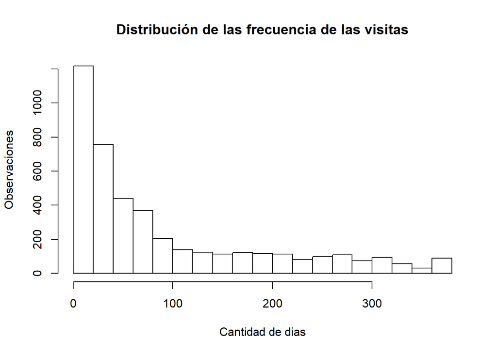

```r
hist(ultima_compra$Recency,
        main = 'Distribución de las frecuencia de las visitas',
        ylab = 'Observaciones',
        xlab = 'Cantidad de dias')
```

```r
datos <-  merge(ultima_compra, visitas_por_cliente, by="CustomerID")
datos <- merge(datos,total_por_cliente, by="CustomerID")
head(datos)
```

```
##   CustomerID UltimaCompra Recency CantidadVisitas    Total
## 1      12346   2011-01-18     325               1 77183.60
## 2      12347   2011-12-07       2               7  4310.00
## 3      12348   2011-09-25      75               4  1797.24
## 4      12349   2011-11-21      18               1  1757.55
## 5      12350   2011-02-02     310               1   334.40
## 6      12352   2011-11-03      36               7  2506.04
```

```r
analysis_date <- lubridate::as_date("2006-12-31", tz = "UTC")
#rfm_result <- rfm_table_order(datos,
#                              customer_id=CustomerID,
#                              order_date=UltimaCompra,
#                              revenue=Total,
#                              max(datos$UltimaCompra))
rfm_result <- rfm_table_order(historic_invoices,
                              customer_id=CustomerID,
                              order_date=InvoiceDay,
                              revenue=Total,
                              max(historic_invoices$InvoiceDay))
#summary(rfm_result)
rfm_result
```

```
## # A tibble: 4,339 x 9
##    customer_id date_most_recent recency_days transaction_cou~ amount
##    <fct>       <date>                  <dbl>            <dbl>  <dbl>
##  1 12346       2011-01-18                325                1 77184.
##  2 12347       2011-12-07                  2                7  4310
##  3 12348       2011-09-25                 75                4  1797.
##  4 12349       2011-11-21                 18                1  1758.
##  5 12350       2011-02-02                310                1   334.
##  6 12352       2011-11-03                 36                7  2506.
##  7 12353       2011-05-19                204                1    89
##  8 12354       2011-04-21                232                1  1079.
##  9 12355       2011-05-09                214                1   459.
## 10 12356       2011-11-17                 22                3  2811.
## # ... with 4,329 more rows, and 4 more variables: recency_score <int>,
## #   frequency_score <int>, monetary_score <int>, rfm_score <dbl>
```

##### Construcción del modelo #1 (Kmedoids)

Para el modelo #1 se hace uso de la técnica Kmedoids.

Para realizar la segmentación de cliente se empleará el análisis RFM para tratar crear variables adicionales, y tratar de agrupar a los clientes según sus caracteristicas.

RFM significa Frescura(Recency) - Frecuencia - Valor monetario. Para efectos del trabajo se intentará identificar si es posible agrupar a los clientes de la compañia analizada en las siguientes categorias.

- Valor bajo: clientes que son menos activos que otros, no son compradores o visitantes muy frecuentes y generan ingresos muy bajos, cero, tal vez negativos.
- Valor medio: en el medio de todo. A menudo, utilizando nuestra plataforma (pero no tanto como nuestros valores altos), es bastante frecuente y genera ingresos moderados.
- Alto valor: el grupo que no queremos perder. Alto ingreso, frecuencia y baja inactividad.

##### Selección de los parámetros modelo #1 (Kmedoids)

*Determinar los clusters optimos*

- Silhoutte
- Método del codo

Otra técnica comunmente utilizada, la estadística gap, no será evaluada, dado que al intentar ejecutarla no se logró que el proceso terminara satisfactoriamente.

A continuación se muestran los resultados de estas técnicas:

```r
rfm_clustering<-rfm_result$rfm[,c("recency_days","transaction_count","amount")]
rfm_clustering <- na.omit(rfm_clustering)

str(rfm_clustering)
```

```
## tibble [4,339 x 3] (S3: tbl_df/tbl/data.frame)
##  $ recency_days     : num [1:4339] 325 2 75 18 310 36 204 232 214 22 ...
##  $ transaction_count: num [1:4339] 1 7 4 1 1 7 1 1 1 3 ...
##  $ amount           : num [1:4339] 77184 4310 1797 1758 334 ...
```

```r
clusters_kmedoids<-pam(rfm_clustering,3)

resultado_medoids <- data.frame(clusters_kmedoids$cluster,rfm_result$rfm)
head(resultado_medoids,20)
```

```
##    clusters_kmedoids.cluster customer_id date_most_recent recency_days
## 1                          1       12346       2011-01-18          325
## 2                          2       12347       2011-12-07            2
## 3                          3       12348       2011-09-25           75
## 4                          3       12349       2011-11-21           18
## 5                          3       12350       2011-02-02          310
## 6                          2       12352       2011-11-03           36
## 7                          3       12353       2011-05-19          204
## 8                          3       12354       2011-04-21          232
## 9                          3       12355       2011-05-09          214
## 10                         2       12356       2011-11-17           22
## 11                         2       12357       2011-11-06           33
## 12                         3       12358       2011-12-08            1
## 13                         2       12359       2011-10-13           57
## 14                         2       12360       2011-10-18           52
```

[output cut: 48 more lines]

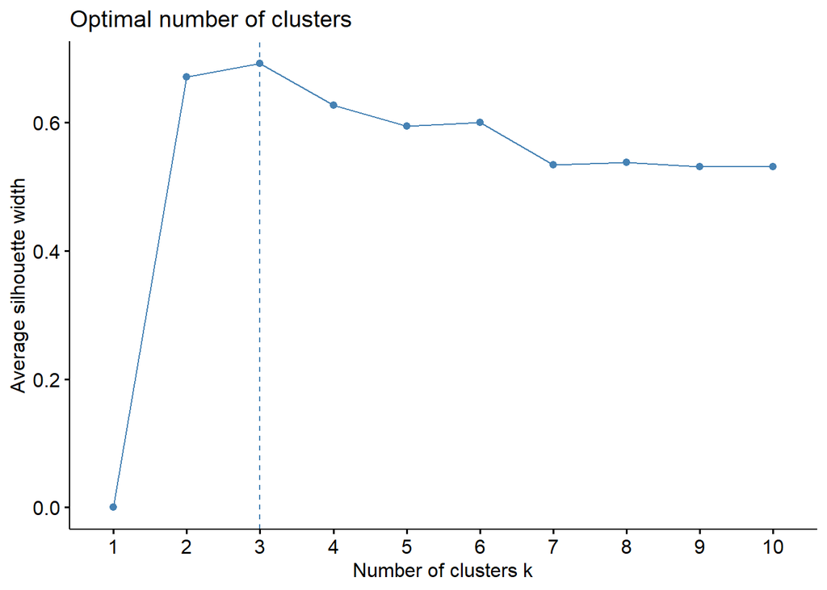

```r
# cálculo del score Silhouette
score_sil<- silhouette(clusters_kmedoids,daisy(rfm_clustering))

# cálculo del valor óptimo de k usando el score silhouette
fviz_nbclust(rfm_clustering,pam,method = 'silhouette',k.max = 10)
```

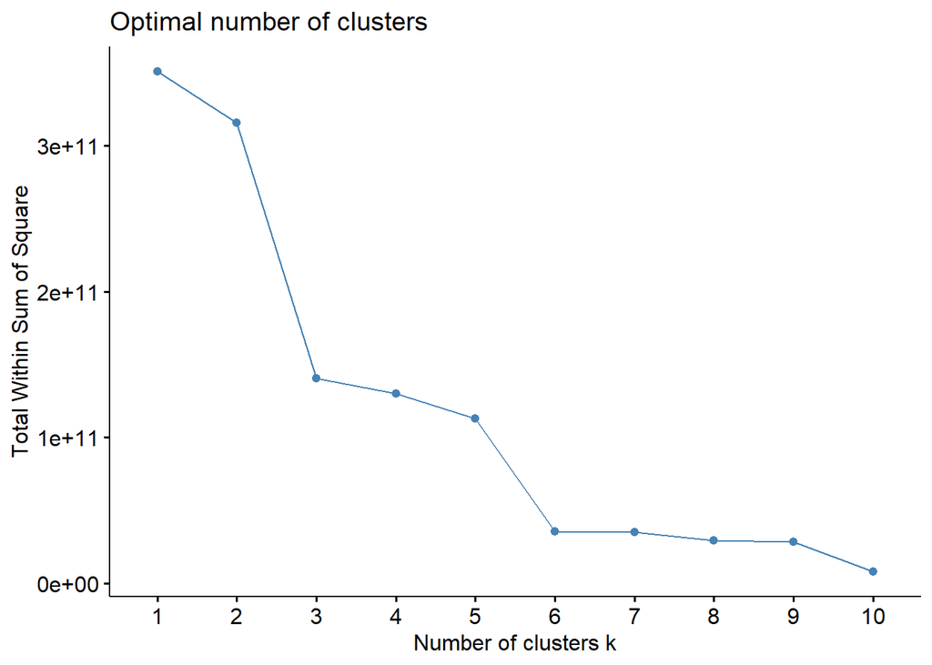

```r
# cálculo del valor óptimo de k usando el método del codo
fviz_nbclust(rfm_clustering,pam,method = 'wss',k.max = 10)
```

```r
# cálculo del valor óptimo de k usando la estadística gap
#fviz_nbclust(rfm_clustering,pam,method = 'gap_stat',k.max = 10)
```

Como se muestra en los graficos anteriores, el método de Silhoutte y el método del codo, parecen mostrar 2 cortes para identificar la cantidad de clusteres óptimos con los valores de 3 y 6. *Considerando que el requerimiento del negocio es agrupar a los clientes en 3 segmentos se utiliza este valor para k, para la creación del número de clusters.*

```r
# cluster al que se asignó cada individuo
clusteres_medoids <- clusters_kmedoids$clustering
#clusteres_medoids
# Descripción de los clusters
medoids <- clusters_kmedoids$medoids
medoids_df <- data.frame(cluster=c("1","2","3"),clusters_kmedoids$medoids, stringsAsFactors = FALSE)

medoids_df$Tecnica<-"KMedoids"

kable(medoids_df,"html", booktabs = T)%>%
  kable_styling(latex_options = "striped")
```

| cluster | recency_days | transaction_count | amount | Tecnica |
| --- | --- | --- | --- | --- |
| 1 | 1 | 29 | 58510.48 | KMedoids |
| 2 | 39 | 7 | 3442.15 | KMedoids |
| 3 | 101 | 2 | 498.42 | KMedoids |

```r
medoids_df
```

```
##   cluster recency_days transaction_count   amount  Tecnica
## 1       1            1                29 58510.48 KMedoids
## 2       2           39                 7  3442.15 KMedoids
## 3       3          101                 2   498.42 KMedoids
```

Como podemos observar en los medoides, los clientes corresponden a grandes rasgos a los siguientes 3 clusters:

- Clientes de bajo valor: Corresponden a los clientes del cluster 3, que tienen pocas compras, de un monto bajo, y no compran recientemente.
- Clientes de valor medio: Corresponden a los clientes del cluster 2, que tienen una cantidad media de compras, compran recientemente, y montos de compras medios
- Clientes de alto valor: Corresponden a los clientes del cluster 1, que tienen una cantidad alta de compras, recientes, y de montos más altos

Podemos observar la visualizacion de los clusters en el siguiente grafico:

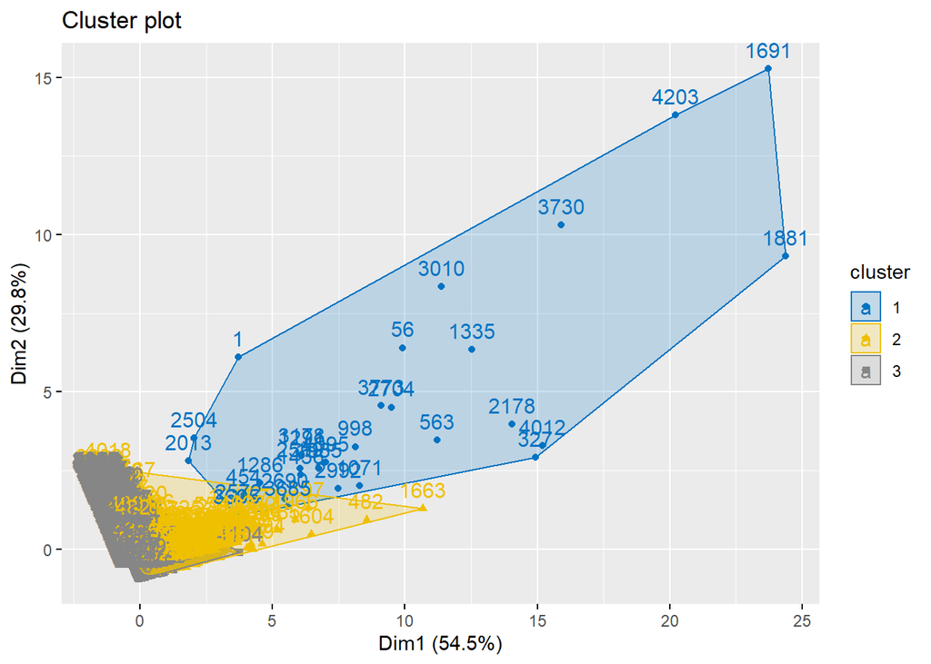

```r
# visualización de los clusters
fviz_cluster(clusters_kmedoids,data=rfm_clustering,palette='jco')
```

Adicionalmente podemos observar la cantidad de clientes asignados a cada cluster:

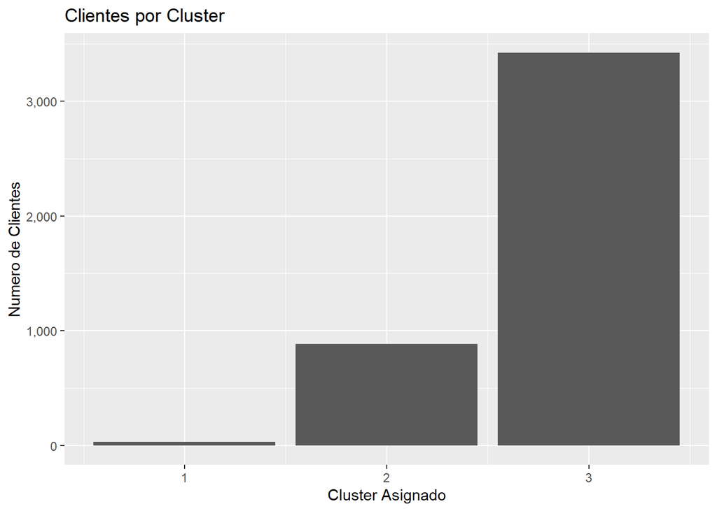

```r
clusters_df<-data.frame(clusters=clusters_kmedoids$clustering)
ggplot(clusters_df,aes(clusters)) +
  geom_bar()+
  scale_y_continuous(name="Numero de Clientes", labels = scales::comma) +
  labs(x="Cluster Asignado")+
  ggtitle("Clientes por Cluster")
```

##### Construcción del modelo #2 (Kmeans)

```r
clusters <- kmeans(rfm_clustering,3,nstart=20)
clusteres_kmeans <- clusters$cluster

# crear un data frame combinando el cluster asignado y los atributos originales
resultado_kmeans <- data.frame(clusters$cluster,rfm_clustering)
head(resultado_kmeans)
```

```
##   clusters.cluster recency_days transaction_count   amount
## 1                3          325                 1 77183.60
## 2                2            2                 7  4310.00
## 3                2           75                 4  1797.24
## 4                2           18                 1  1757.55
## 5                2          310                 1   334.40
## 6                2           36                 7  2506.04
```

De los clusteres anteriores se puede observar como la variable recency no parece tener tanta significancia y los grupos tienen a tener una relación en cuanto al valor monetario invertido por cada cliente.

```r
#obtener cantidad de registros en cada cluster y los centroides
centroides<- data.frame(clusters$size,clusters$centers)
centroides$Tecnica<-"KMeans"
centroides$clusters.size<-NULL
centroides$cluster<-rownames(centroides)
centroides
```

```
##   recency_days transaction_count     amount Tecnica cluster
## 1      2.00000         46.400000 209342.334  KMeans       1
## 2     92.56622          3.611059   1455.321  KMeans       2
## 3     31.76667         33.066667  53366.486  KMeans       3
```

###### Descripción del modelo obtenido (Incluya al menos un gráfico)

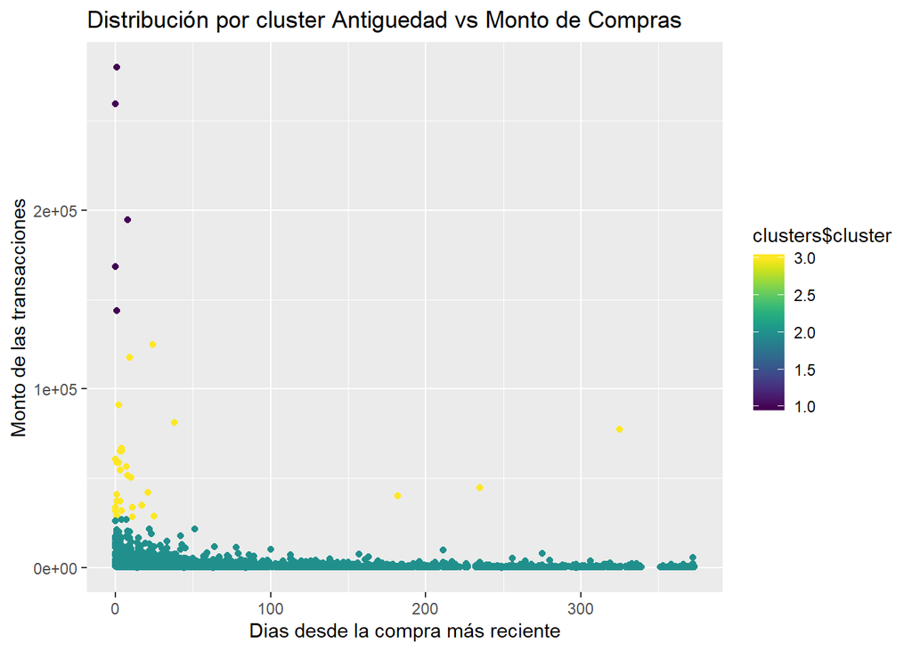

```r
ggplot(rfm_clustering,aes(rfm_clustering$recency_days,rfm_clustering$amount, color = clusters$cluster)) + geom_point()+
  ggtitle(label='Distribución por cluster Antiguedad vs Monto de Compras') +
  scale_color_viridis(option = "D") +
  labs(y="Monto de las transacciones",x="Dias desde la compra más reciente")
```

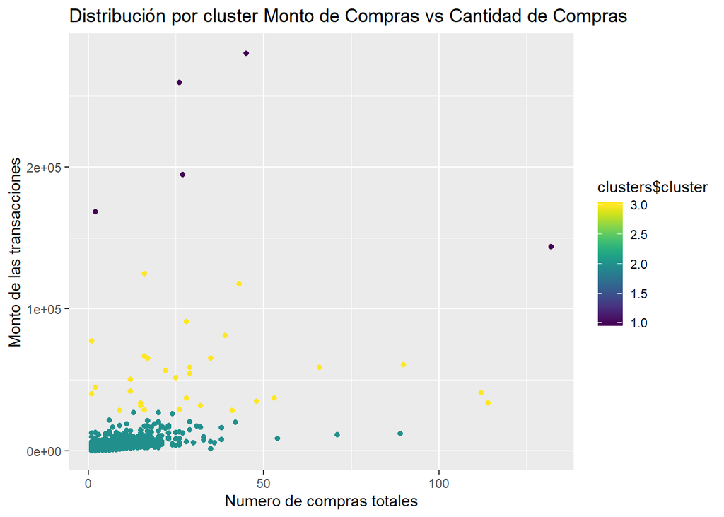

```r
ggplot(rfm_clustering,aes(rfm_clustering$transaction_count,rfm_clustering$amount, color = clusters$cluster)) + geom_point()+
  ggtitle(label='Distribución por cluster Monto de Compras vs Cantidad de Compras') +
  scale_color_viridis(option = "D") +
  labs(y="Monto de las transacciones",x="Numero de compras totales")
```

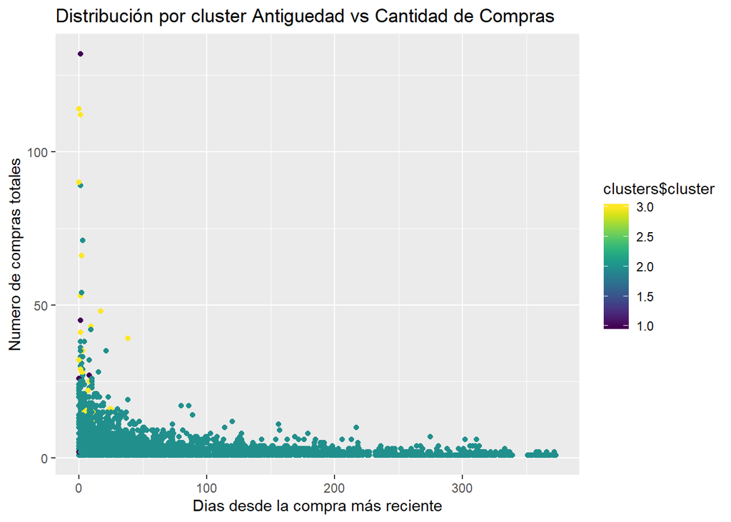

```r
ggplot(rfm_clustering,aes(rfm_clustering$recency_days,rfm_clustering$transaction_count, color = clusters$cluster)) + geom_point()+
  ggtitle(label='Distribución por cluster Antiguedad vs Cantidad de Compras') +
  scale_color_viridis(option = "D") +
  labs(y="Numero de compras totales",x="Dias desde la compra más reciente")
```

El siguiente gráfico muestra el detalle de los clusters creados.

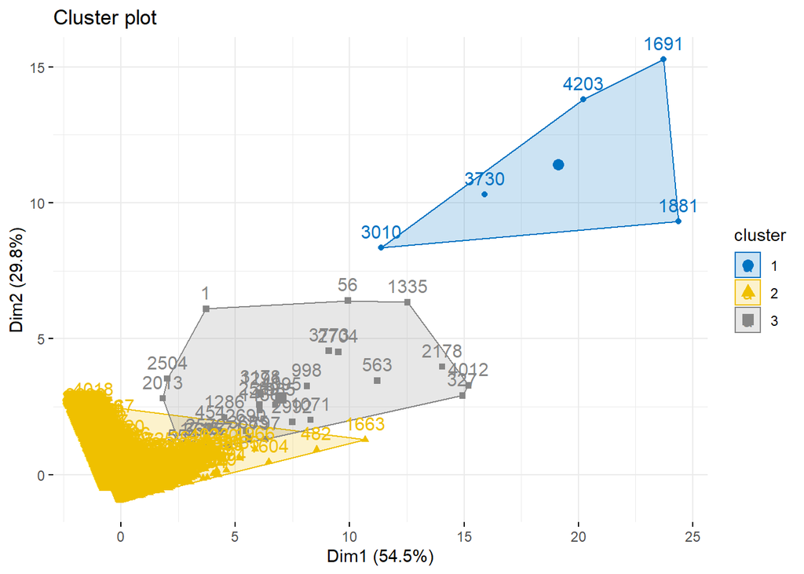

```r
# otra forma de visualizar los clusters
fviz_cluster(clusters,data=rfm_clustering,palette='jco',ggtheme = theme_minimal())
```

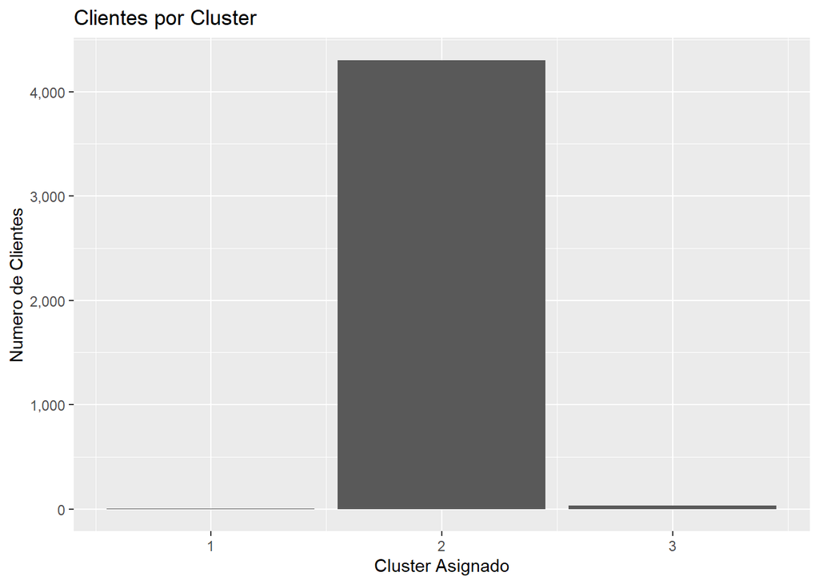

```r
clusters_dfkmeans<-data.frame(clusters=clusters$cluster)
ggplot(clusters_dfkmeans,aes(clusters)) +
  geom_bar()+
  scale_y_continuous(name="Numero de Clientes", labels = scales::comma) +
  labs(x="Cluster Asignado")+
  ggtitle("Clientes por Cluster")
```

```r
export_df<-rfm_result$rfm
export_df$kmedoids<-clusters_kmedoids$clustering
export_df$kmeans<-clusters$cluster
head(export_df)
```

```
## # A tibble: 6 x 11
##   customer_id date_most_recent recency_days transaction_cou~ amount
##   <fct>       <date>                  <dbl>            <dbl>  <dbl>
## 1 12346       2011-01-18                325                1 77184.
## 2 12347       2011-12-07                  2                7  4310
## 3 12348       2011-09-25                 75                4  1797.
## 4 12349       2011-11-21                 18                1  1758.
## 5 12350       2011-02-02                310                1   334.
## 6 12352       2011-11-03                 36                7  2506.
## # ... with 6 more variables: recency_score <int>, frequency_score <int>,
## #   monetary_score <int>, rfm_score <dbl>, kmedoids <int>, kmeans <int>
```

```r
summary(export_df)
```

```
##   customer_id   date_most_recent      recency_days    transaction_count
##  12346  :   1   Min.   :2010-12-01   Min.   :  0.00   Min.   :  1.000
##  12347  :   1   1st Qu.:2011-07-20   1st Qu.: 17.00   1st Qu.:  1.000
##  12348  :   1   Median :2011-10-20   Median : 50.00   Median :  2.000
##  12349  :   1   Mean   :2011-09-07   Mean   : 92.04   Mean   :  3.864
##  12350  :   1   3rd Qu.:2011-11-22   3rd Qu.:141.50   3rd Qu.:  4.000
##  12352  :   1   Max.   :2011-12-09   Max.   :373.00   Max.   :132.000
##  (Other):4333
##      amount         recency_score   frequency_score monetary_score
##  Min.   :     0.0   Min.   :1.000   Min.   :1.000   Min.   :1.000
##  1st Qu.:   307.2   1st Qu.:2.000   1st Qu.:1.000   1st Qu.:2.000
##  Median :   674.5   Median :3.000   Median :2.000   Median :3.000
##  Mean   :  2053.8   Mean   :3.016   Mean   :2.595   Mean   :2.999
##  3rd Qu.:  1661.6   3rd Qu.:4.000   3rd Qu.:4.000   3rd Qu.:4.000
##  Max.   :280206.0   Max.   :5.000   Max.   :5.000   Max.   :5.000
##
##    rfm_score        kmedoids         kmeans
##  Min.   :111.0   Min.   :1.000   Min.   :1.000
##  1st Qu.:212.0   1st Qu.:3.000   1st Qu.:2.000
##  Median :323.0   Median :3.000   Median :2.000
##  Mean   :330.6   Mean   :2.782   Mean   :2.006
##  3rd Qu.:454.0   3rd Qu.:3.000   3rd Qu.:2.000
##  Max.   :555.0   Max.   :3.000   Max.   :3.000
##
```

```r
export_df<- merge(x=export_df,y=clientes_pais,by.x="customer_id",by.y="CustomerID")
head(export_df)
```

```
##   customer_id date_most_recent recency_days transaction_count   amount
## 1       12346       2011-01-18          325                 1 77183.60
## 2       12347       2011-12-07            2                 7  4310.00
## 3       12348       2011-09-25           75                 4  1797.24
## 4       12349       2011-11-21           18                 1  1757.55
## 5       12350       2011-02-02          310                 1   334.40
## 6       12352       2011-11-03           36                 7  2506.04
##   recency_score frequency_score monetary_score rfm_score kmedoids kmeans
## 1             1               1              5       115        1      3
## 2             5               5              5       555        2      2
## 3             2               4              4       244        3      2
## 4             4               1              4       414        3      2
## 5             1               1              2       112        3      2
## 6             3               5              5       355        2      2
##          Country
## 1 United Kingdom
## 2        Iceland
## 3        Finland
## 4          Italy
## 5         Norway
## 6         Norway
```

```r
summary(export_df)
```

```
##   customer_id   date_most_recent      recency_days    transaction_count
##  12346  :   1   Min.   :2010-12-01   Min.   :  0.00   Min.   :  1.000
##  12347  :   1   1st Qu.:2011-07-20   1st Qu.: 17.00   1st Qu.:  1.000
##  12348  :   1   Median :2011-10-20   Median : 50.00   Median :  2.000
##  12349  :   1   Mean   :2011-09-07   Mean   : 92.04   Mean   :  3.864
##  12350  :   1   3rd Qu.:2011-11-22   3rd Qu.:141.50   3rd Qu.:  4.000
##  12352  :   1   Max.   :2011-12-09   Max.   :373.00   Max.   :132.000
##  (Other):4333
##      amount         recency_score   frequency_score monetary_score
##  Min.   :     0.0   Min.   :1.000   Min.   :1.000   Min.   :1.000
##  1st Qu.:   307.2   1st Qu.:2.000   1st Qu.:1.000   1st Qu.:2.000
##  Median :   674.5   Median :3.000   Median :2.000   Median :3.000
##  Mean   :  2053.8   Mean   :3.016   Mean   :2.595   Mean   :2.999
##  3rd Qu.:  1661.6   3rd Qu.:4.000   3rd Qu.:4.000   3rd Qu.:4.000
##  Max.   :280206.0   Max.   :5.000   Max.   :5.000   Max.   :5.000
##
##    rfm_score        kmedoids         kmeans                Country
##  Min.   :111.0   Min.   :1.000   Min.   :1.000   United Kingdom:3921
##  1st Qu.:212.0   1st Qu.:3.000   1st Qu.:2.000   Germany       :  94
##  Median :323.0   Median :3.000   Median :2.000   France        :  87
##  Mean   :330.6   Mean   :2.782   Mean   :2.006   Spain         :  28
##  3rd Qu.:454.0   3rd Qu.:3.000   3rd Qu.:2.000   Belgium       :  24
##  Max.   :555.0   Max.   :3.000   Max.   :3.000   Switzerland   :  20
##                                                  (Other)       : 165
```

```r
export_df<-export_df %>%
  mutate(kmeans = replace(kmeans, kmeans == 1, "2 Medio Valor")) %>%
  mutate(kmeans = replace(kmeans, kmeans == 3, "1 Alto Valor")) %>%
  mutate(kmeans = replace(kmeans, kmeans == 2, "3 Bajo Valor")) %>%
  mutate(kmedoids = replace(kmedoids, kmedoids == 2, "2 Medio Valor")) %>%
  mutate(kmedoids = replace(kmedoids, kmedoids == 1, "1 Alto Valor")) %>%
  mutate(kmedoids = replace(kmedoids, kmedoids == 3, "3 Bajo Valor"))

write.csv(export_df,"resultado_cluster.csv")

centroides2<-centroides %>%
  mutate(cluster = replace(cluster, cluster == "1", "2 Medio Valor")) %>%
  mutate(cluster = replace(cluster, cluster == "3", "1 Alto Valor")) %>%
  mutate(cluster = replace(cluster, cluster == "2", "3 Bajo Valor"))

medoids_df2 <- medoids_df %>%
  mutate(cluster = replace(cluster, cluster == "2", "2 Medio Valor")) %>%
  mutate(cluster = replace(cluster, cluster == "1", "1 Alto Valor")) %>%
  mutate(cluster = replace(cluster, cluster == "3", "3 Bajo Valor"))


export_clusters <- rbind(medoids_df2,centroides2)

write.csv(export_clusters,"centros_clusters.csv")
```

```r
mdf<-medoids_df2
mdf$Tecnica<-NULL
colnames(mdf)<-c("Segmento","Antiguedad","Cantidad de Transacciones","Montos")
kable(mdf,"html", booktabs = T)%>%
  kable_styling(bootstrap_options = c("striped", "hover"), full_width = F, position = "left")
```

| Segmento | Antiguedad | Cantidad de Transacciones | Montos |
| --- | --- | --- | --- |
| 1 Alto Valor | 1 | 29 | 58510.48 |
| 2 Medio Valor | 39 | 7 | 3442.15 |
| 3 Bajo Valor | 101 | 2 | 498.42 |

### Modelos de regresión

Para este proyecto se emplearán las técnicas de regresión simple y regresión múltiple a fin de comparar los resultados de ambas al realizar la predicción de las ventas.

#### Selección de los parámetros

Para la construccion de los modelos de regresión se trabajara con el campo InvoiceDay y los montos de ventas, a fin de realizar la agregación de las ventas por la fecha de compras y poder monitorear el comportamiento mensual de las mismas y a partir de estos datos generar otras variables que nos sean de utilidad para la predicción.

```r
retail$YearMonth <- format(as.Date(retail$InvoiceDay), "%Y-%m")
compras <- retail %>%
  group_by(InvoiceDay) %>%
  summarise_at(vars(Total),funs(sum(.)))

colnames(compras) <- c('Fecha','ventas')
kable(head(compras,10),"html", booktabs = T)%>%
  kable_styling(latex_options = "striped")
```

| Fecha | ventas |
| --- | --- |
| 2010-12-01 | 58635.56 |
| 2010-12-02 | 46207.28 |
| 2010-12-03 | 45620.46 |
| 2010-12-05 | 31383.95 |
| 2010-12-06 | 53860.18 |
| 2010-12-07 | 45059.05 |
| 2010-12-08 | 44189.84 |
| 2010-12-09 | 52532.13 |
| 2010-12-10 | 57404.91 |
| 2010-12-12 | 17240.92 |

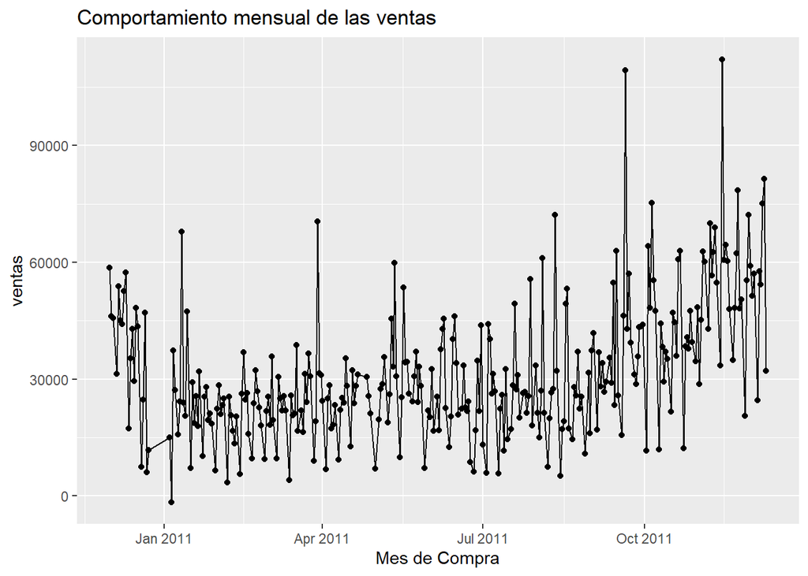

```r
ggplot(data=compras, aes(x=Fecha, y=ventas, group=1)) +
  geom_line()+
  geom_point() +
  labs(x="Mes de Compra")+
  ggtitle("Comportamiento mensual de las ventas")
```

El siguiente paso a ejecutar es comparar la diferencia en ventas con la fecha predecesora.

```r
compras_diferencia <- compras
compras_diferencia['ventas_previas'] <- shift(compras_diferencia$ventas,n=1,fill=0)
compras_diferencia <- na.omit(compras_diferencia)
# se procede a calcular la diferencia
compras_diferencia['diff'] <- compras_diferencia$ventas - compras_diferencia$ventas_previas
```

Al analizar el comportamiento de las ventas a lo largo del tiempo se observa que el comportamiento de las mismas pareciera tener un comportamiento similar a lo largo de todo el año, y se observa un incremento en las ventas a fin de mes.

Posterior a esto se procede a crear las variables lag, las cuales nos permiten representar como columnas las ventas y el comportamiento de las mismas durante el periodo de un año.

La razón por la cual se crean 13 variables lag es debido a que por cada mes se tienen observaciones unicamente de alrededor de 13 dias.

```r
for (inc in 0:12){
  field_name = paste('lag',toString(inc),sep = '')
  compras_diferencia[field_name] <- shift(compras_diferencia$diff,n=inc,fill=0)
}

compras_diferencia <- na.omit(compras_diferencia)
colnames(compras_diferencia) <- c('Fecha', 'Ventas', 'Ventas_previas', 'diff', 'lag1','lag2','lag3','lag4','lag5','lag6','lag7','lag8','lag9','lag10','lag11','lag12','lag13')
```

```r
#Se particiona el dataset en entrenamiento y prueba.
#entrenamiento = compras_diferencia[compras_diferencia$Fecha <= '2011-10-31',]
#prueba  = compras_diferencia[compras_diferencia$Fecha >= '2011-10-31',]
sample = sample.split(compras_diferencia$Ventas, SplitRatio = .75)
entrenamiento = subset(compras_diferencia, sample == TRUE)
prueba  = subset(compras_diferencia, sample == FALSE)
```

```r
cor(entrenamiento[4:17])
```

```
##               diff         lag1        lag2        lag3        lag4
## diff   1.000000000  1.000000000 -0.37585967 -0.14479723  0.03360643
## lag1   1.000000000  1.000000000 -0.37585967 -0.14479723  0.03360643
## lag2  -0.375859670 -0.375859670  1.00000000 -0.39975901 -0.12668416
## lag3  -0.144797230 -0.144797230 -0.39975901  1.00000000 -0.40862208
## lag4   0.033606433  0.033606433 -0.12668416 -0.40862208  1.00000000
## lag5  -0.001702403 -0.001702403  0.07057957 -0.11084058 -0.41276216
## lag6  -0.197901755 -0.197901755 -0.03116299  0.05161705 -0.09481433
## lag7   0.413619827  0.413619827 -0.20400594 -0.04903334  0.08778047
## lag8  -0.142958386 -0.142958386  0.42398559 -0.18882330 -0.10420388
## lag9  -0.102014528 -0.102014528 -0.16428000  0.44068579 -0.12839415
## lag10  0.125207232  0.125207232 -0.18232408 -0.14780924  0.44346268
## lag11 -0.156141534 -0.156141534  0.17681712 -0.18574631 -0.17407434
## lag12 -0.098915360 -0.098915360 -0.12815275  0.14654171 -0.14871882
## lag13  0.335840274  0.335840274 -0.08929259 -0.12141131  0.09058690
##               lag5         lag6        lag7         lag8         lag9
## diff  -0.001702403 -0.197901755  0.41361983 -0.142958386 -0.102014528
## lag1  -0.001702403 -0.197901755  0.41361983 -0.142958386 -0.102014528
## lag2   0.070579573 -0.031162990 -0.20400594  0.423985594 -0.164279996
## lag3  -0.110840584  0.051617047 -0.04903334 -0.188823300  0.440685785
## lag4  -0.412762156 -0.094814327  0.08778047 -0.104203880 -0.128394151
## lag5   1.000000000 -0.450544964 -0.07240886  0.094117401 -0.073760073
## lag6  -0.450544964  1.000000000 -0.44991892 -0.076634434  0.018390853
## lag7  -0.072408862 -0.449918922  1.00000000 -0.413415172 -0.144550532
## lag8   0.094117401 -0.076634434 -0.41341517  1.000000000 -0.415048830
## lag9  -0.073760073  0.018390853 -0.14455053 -0.415048830  1.000000000
## lag10 -0.190122884 -0.008913043  0.10918567 -0.205304500 -0.365834934
## lag11  0.440367821 -0.174530034 -0.03560598  0.071359383 -0.095150992
## lag12 -0.158459425  0.422904418 -0.19616595 -0.004602065  0.005783609
## lag13 -0.136641821 -0.143347123  0.41745801 -0.135398792 -0.065076956
##              lag10       lag11        lag12       lag13
## diff   0.125207232 -0.15614153 -0.098915360  0.33584027
## lag1   0.125207232 -0.15614153 -0.098915360  0.33584027
## lag2  -0.182324083  0.17681712 -0.128152748 -0.08929259
## lag3  -0.147809243 -0.18574631  0.146541715 -0.12141131
## lag4   0.443462678 -0.17407434 -0.148718823  0.09058690
## lag5  -0.190122884  0.44036782 -0.158459425 -0.13664182
## lag6  -0.008913043 -0.17453003  0.422904418 -0.14334712
## lag7   0.109185675 -0.03560598 -0.196165954  0.41745801
## lag8  -0.205304500  0.07135938 -0.004602065 -0.13539879
## lag9  -0.365834934 -0.09515099  0.005783609 -0.06507696
## lag10  1.000000000 -0.46218597 -0.087470786  0.07378374
## lag11 -0.462185968  1.00000000 -0.359889726 -0.14846223
## lag12 -0.087470786 -0.35988973  1.000000000 -0.45185674
## lag13  0.073783745 -0.14846223 -0.451856740  1.00000000
```

#### Modelo de Regresión lineal simple

Para le modelo de regresión simple se utilizara únicamente la variable lag1.

```r
#Se crea la regresion lineal simple para la diferencia de las ventas
modelo.simple <- lm(Ventas ~ lag1, data = entrenamiento)
#ver detalle del modelo
summary(modelo.simple)
```

```
##
## Call:
## lm(formula = Ventas ~ lag1, data = entrenamiento)
##
## Residuals:
##    Min     1Q Median     3Q    Max
## -24551 -10273  -3397   8099  46346
##
## Coefficients:
##              Estimate Std. Error t value Pr(>|t|)
## (Intercept) 3.173e+04  9.692e+02   32.74   <2e-16 ***
## lag1        5.296e-01  4.985e-02   10.62   <2e-16 ***
## ---
## Signif. codes:  0 '***' 0.001 '**' 0.01 '*' 0.05 '.' 0.1 ' ' 1
##
## Residual standard error: 14630 on 226 degrees of freedom
## Multiple R-squared:  0.3331, Adjusted R-squared:  0.3301
## F-statistic: 112.9 on 1 and 226 DF,  p-value: < 2.2e-16
```

Al analizar la significancia estadistica de la variable lag1 se puede observar que esta presenta una alta significancia, para el modelo de predicción.

##### Evaluación Modelo de regresión lineal simple

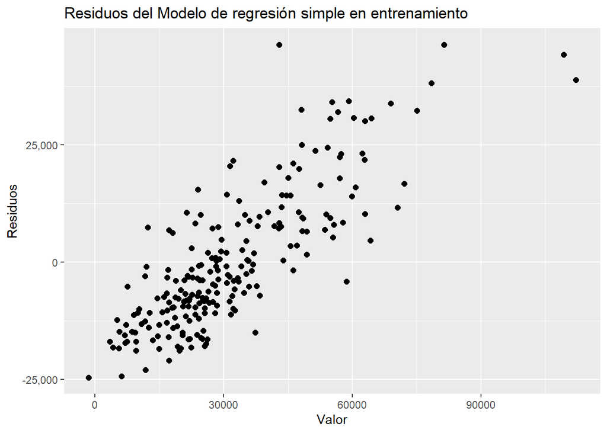

```r
# Ver distribución de los residuos del modelo

ggplot(entrenamiento,aes(x=entrenamiento$Ventas,y = modelo.simple$residuals)) +
  geom_point(size=2) +
  labs(x="Valor",y="Residuos")+
  ggtitle("Residuos del Modelo de regresión simple en entrenamiento")+
  scale_y_continuous(labels = scales::comma)
```

```r
#Se realizan las predicciones empleando el conjunto de datos de entrenamiento.
entrenamiento$Prediccion <- predict(modelo.simple)

# predecir valores de diff en el conjunto de datos de prueba
prueba$Prediccion <- predict(modelo.simple, newdata = prueba)
```

```r
confint(modelo.simple)
```

```
##                    2.5 %       97.5 %
## (Intercept) 2.982234e+04 3.364206e+04
## lag1        4.313633e-01 6.278137e-01
```

```r
#Residual Standard Error (RSE)
sigma(modelo.simple)/mean(prueba$Ventas)
```

```
## [1] 0.4420712
```

```r
entrenamiento$Observacion <- 'entrenamiento'
prueba$Observacion <- 'prueba'

resultados_rs <- rbind(entrenamiento,prueba)
resultados_rs$Modelo <- 'Regresión Simple'
```

##### Comparación de ventas reales vrs prediciones

Como se puede apreciar en los gráficos a continuación la predición de las ventas se comporta de manera muy similar a las ventas históricas. Durante el mes de mayo se observa una variación en las ventas reales, se observa un incremento en las ventas y posterior a esto una disminución, en el caso de las predicciones pareciera que el modelo no parecer ser capaz de predecir este comportamiento el cual podria analizarse si es una anomalia o si por el contrario se debe sobreajustar el modelo para que sea capaz de predecir estos cambios.

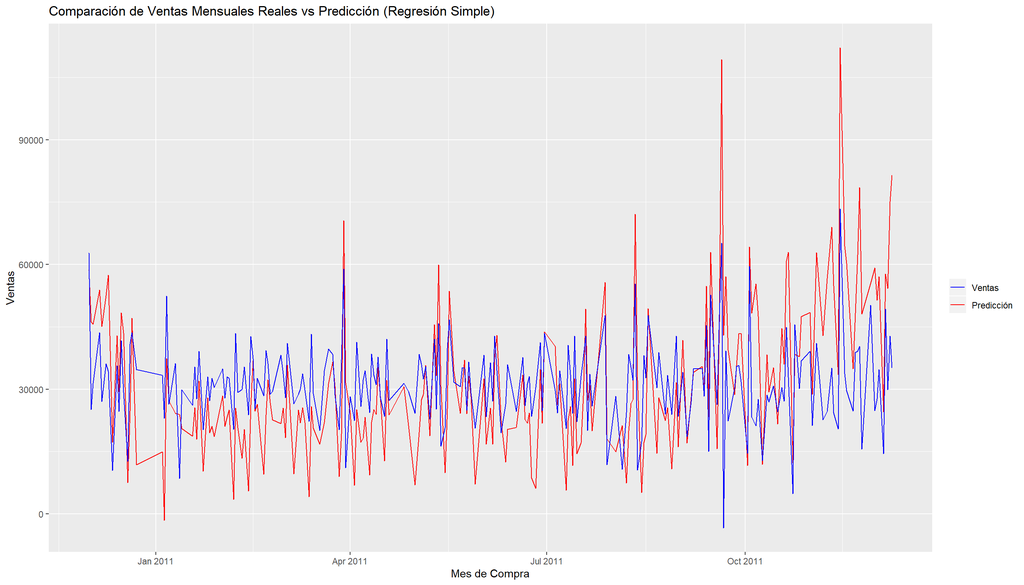

```r
p <- ggplot() +
  geom_line(data=entrenamiento, aes(x=Fecha, y=Ventas, group=1, colour = "Ventas")) +
  geom_line(data=entrenamiento, aes(x=Fecha, y=Prediccion, group=1, colour = "Predicción"))+
  geom_point()+
  labs(x="Mes de Compra")+
  ggtitle("Comparación de Ventas Mensuales Reales vs Predicción (Regresión Simple)")+
  scale_colour_manual("",labels = c("Ventas", "Predicción"), values = c("blue", "red"))
p
```

#### Modelos Regresión Multiple

```r
#Para la creación del modelo 1 se empezará por un modelo "completo"
modelo.multiple0 <- lm(Ventas ~ lag1 + lag2 + lag3 + lag4 + lag5 + lag6 + lag7, data = entrenamiento)
# ver el detalle del resumen
summary(modelo.multiple0)
```

```
##
## Call:
## lm(formula = Ventas ~ lag1 + lag2 + lag3 + lag4 + lag5 + lag6 +
##     lag7, data = entrenamiento)
##
## Residuals:
##    Min     1Q Median     3Q    Max
## -23275  -8204  -3189   6171  33798
##
## Coefficients:
##              Estimate Std. Error t value Pr(>|t|)
## (Intercept) 3.106e+04  7.616e+02  40.780  < 2e-16 ***
## lag1        8.673e-01  5.213e-02  16.635  < 2e-16 ***
## lag2        7.447e-01  6.408e-02  11.621  < 2e-16 ***
## lag3        6.007e-01  7.072e-02   8.494 3.01e-15 ***
## lag4        4.907e-01  7.304e-02   6.718 1.55e-10 ***
## lag5        2.757e-01  7.424e-02   3.713 0.000259 ***
## lag6        1.805e-01  6.681e-02   2.702 0.007433 **
## lag7        1.027e-01  5.587e-02   1.838 0.067339 .
## ---
## Signif. codes:  0 '***' 0.001 '**' 0.01 '*' 0.05 '.' 0.1 ' ' 1
##
## Residual standard error: 11450 on 220 degrees of freedom
## Multiple R-squared:  0.6022, Adjusted R-squared:  0.5896
## F-statistic: 47.59 on 7 and 220 DF,  p-value: < 2.2e-16
```

###### Evaluación Modelo Regresión Múltiple 1

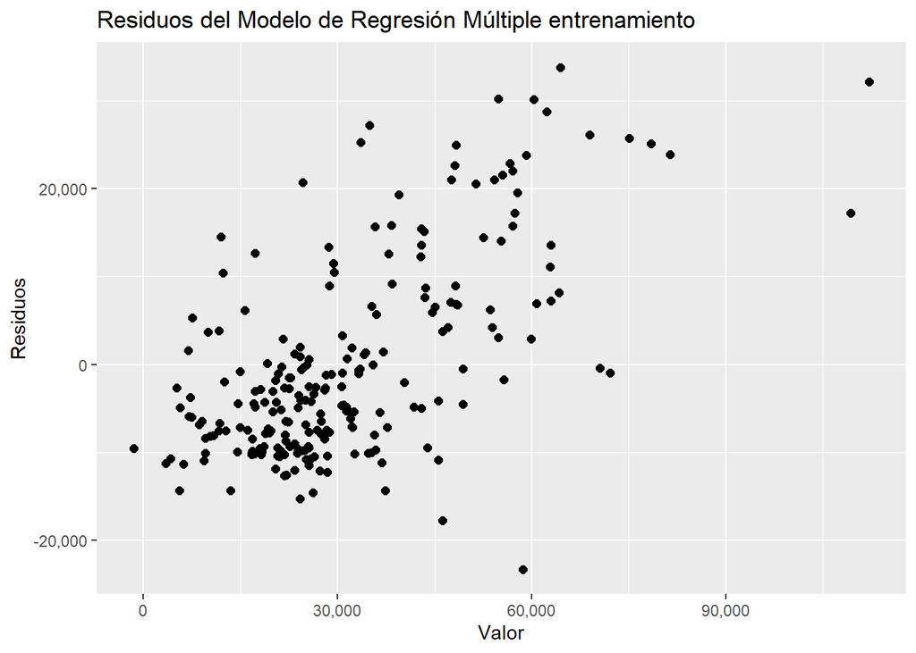

```r
# Ver distribución de los residuos del modelo

ggplot(entrenamiento,aes(x=entrenamiento$Ventas,y = modelo.multiple0$residuals)) +
  geom_point(size=2) +
  labs(x="Valor",y="Residuos")+
  ggtitle("Residuos del Modelo de Regresión Múltiple entrenamiento")+
  scale_y_continuous(labels = scales::comma) +
  scale_x_continuous(labels = scales::comma)
```

```r
#Predicción usando los datos de entrenamiento.
entrenamiento$Prediccion <- predict(modelo.multiple0)

# predecir valores de la diferencia de compras usando el dataset de pruebas
prueba$Prediccion <- predict(modelo.multiple0, newdata = prueba[,4:15])

#entrenamiento[,c(1,4,18)]
#prueba[,c(1,4,18)]
```

##### Comparación de ventas reales vrs prediciones

Como se puede apreciar en los gráficos a continuación la predición de la diferencia de las ventas se comporta de manera muy similar a las ventas históricas, de igual manera se observa que el modelo se comporta de forma muy similar al comportamiento de regresión lineal simple.

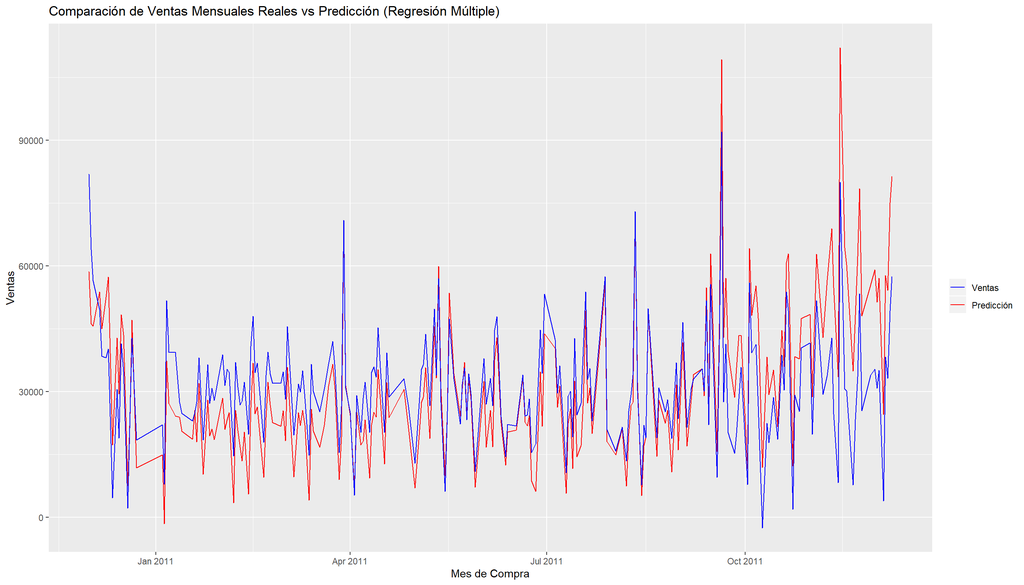

```r
p <- ggplot() +
  geom_line(data=entrenamiento, aes(x=Fecha, y=Ventas, group=1, colour = "Ventas")) +
  geom_line(data=entrenamiento, aes(x=Fecha, y=Prediccion, group=1, colour = "Predicción"))+
  geom_point()+
  labs(x="Mes de Compra")+
  ggtitle("Comparación de Ventas Mensuales Reales vs Predicción (Regresión Múltiple)")+
  scale_colour_manual("",labels = c("Ventas", "Predicción"), values = c("blue", "red"))
p
```

Para extraer el intervalo de confianza del modelo se utiliza la función confint

```r
confint(modelo.multiple0)
```

```
##                     2.5 %       97.5 %
## (Intercept)  2.955769e+04 3.255971e+04
## lag1         7.645105e-01 9.700016e-01
## lag2         6.183915e-01 8.709777e-01
## lag3         4.612780e-01 7.400134e-01
## lag4         3.467311e-01 6.346215e-01
## lag5         1.293625e-01 4.220048e-01
## lag6         4.883961e-02 3.121771e-01
## lag7        -7.393293e-03 2.128365e-01
```

```r
#Residual Standard Error (RSE)
sigma(modelo.multiple0)/mean(prueba$Ventas)
```

```
## [1] 0.346023
```

Podemos ver que el sigma es de 0.346023 para el modelo de regresión múltiple.

Se procede a exportar los datos a un archivo csv para la creación de los dashboards

```r
entrenamiento$Observacion <- 'entrenamiento'
prueba$Observacion <- 'prueba'
resultados_rm <- rbind(entrenamiento,prueba)
resultados_rm$Modelo <- 'Regresión Multiple'


resultado_regresion <- rbind(resultados_rs,resultados_rm)
resultado_regresion$Test <- as.Date(resultado_regresion$Fecha, format = '%Y%m%d')
write.csv(resultado_regresion, "resultado_regresion.csv")
```

## Evaluación de los modelos y selección

### Regresión - Regresión Múltiple

A pesar de que los resultados obtenidos por ambos modelos, no se consideran buenos debido a la alta tasa de error, si se recomienda usar el modelo de regresión múltiple el cual es el que ofrece los mejores resultados.

# Dashboard

Para la representación de los resultados se crearon 2 Dashboards los cuales muestran los resultados de los modelos de clustering y responden a la pregunta de los diferentes segmentos de mercado que se encontraron a través de las caracteristicas de las compras de los clientes, basado en su antiguedad, frecuencia de compras y montos de compra.

El segundo dashboard presenta los resultados del modelo de regresión multiple y lineal para la predicción de las ventas.

Los dashboard publicados se encuentran disponibles a través de Tableau Public.

- https://public.tableau.com/profile/eilyn.francinie.salazar.miranda#!/vizhome/ProyectoFinal_CursoMineria_EspecializacionCD/Resumensegmentosdemercado?publish=yes